# Laboratórios de Estatística Básica com R

# Sobre o projeto

Este curso é uma adaptação dos laboratórios de estatística disponíveis no livro **OpenIntro Statistics: Labs for R** (BRAY; ÇETINKAYA-RUNDEL; KUYPER, 2019). Aqui, usamos as principais biliotecas do R para desenvolver aquilo que é proposto nos capítulos (laboratórios) do livro. Em cada caso, usamos também gráficos e tabelas para auxiliar no aprendizado dos conceitos estatísticos envolvidos.

Todas as análises realizadas neste livro são subsidiadas por bases de dados reais, públicas, disponibilizadas pelos autores do livro (OPENINTRO, [*s. d.*]). Além disso, como bibliografia complementar, utilizamos o livro-texto de Estatística Básica dos autores Bussab & Morettin (MORETTIN; BUSSAB, 2017).

# Lab01: Introdução ao R e ao Rstudio

O R é um poderoso software estatístico. Com ele, é possível fazer desde cálculos simples envolvendo distribuições de probabilidades e estatística descritiva até o desenvolvimento de modelos de machine learning.

A linguagem R foi desenvolvida na década de 90 por dois estatísticos Neozelandêses, Ross Ihaka e Robert Gentleman (daí o nome R). O R é um software livre e de código aberto. Atualmente possui uma vasta biblioteca de funções para cálculos estatísticos e possui uma grande comunidade que contribui com o projeto (R-PROJECT, [*s. d.*]).

As distribuições linux geralmente já contêm o R. Para as demais, o software pode ser baixado através da página do projeto: https://cran.r-project.org/.

O Rstudio, por sua vez, é uma IDE (Integrated Development Enviroment) ou Ambiente de Desenvolvimento Integrado. Genericamente falando, uma IDE é um programa que, com sua interface gráfica amigável (mais parecida com os programas voltados ao usuário comum), traz uma série de ferramentas que facilitam o desenvolvimento de aplicações. Algumas dessas ferramentas são compilador e um editor de código-fonte capaz de apontar erros e sugerir a sintáxe correta das funções (WIKIPÉDIA, [*s. d.*]).

O Rstudio, a exemplo do R, também é um software gratuito e de código aberto. Porém, diferentemente do R, esta IDE possui também uma versão paga. Para baixar a ferramenta, basta acessar a página oficial: https://posit.co/download/rstudio-desktop/.

## Conteúdos abordados neste laboratório

- Primeiros passos no R e no Rstudio
- Explorando uma base de dados carregada da nuvem
- fazendo filtros e gráficos com o R

## Carregamento de pacotes

O R é uma linguagem de programação de código aberto, o que significa que os usuários podem contribuir com pacotes que facilitam nossas vidas. Ainda melhor, podemos usá-las gratuitamente. Para este laboratório, e muitos outros futuros, usaremos principalmente os seguintes pacotes do R:

- `dplyr`: para descrição de dados
- `ggplot2`: para visualização de dados
- `kableExtra`: Para deixar as saídas de dados em formato de tabela
- `rmarkdown`: para fazer relatórios como este, usando markdown

Para carregá-los no nosso ambiente de trabalho, digitamos no console:

```r
library(ggplot2)
library(plyr)
library(tidyr)
library(dplyr)
library(DescTools)
library(htmltools)
library(knitr)
library(rmarkdown)
library(combinat)
library(kableExtra) #Para gerar tabelas com um layout agradável
```

## Os dados: Registros de batismos do Dr. Arbuthnot

Aqui, vamos carregar os dados diretamente da itnernet, na página do *OpenIntro Statistics*:

```r
source("http://www.openintro.org/stat/data/arbuthnot.R")
```

O conjunto de dados Arbuthnot se refere ao Dr. John Arbuthnot, um médico, escritor e matemático do século 18. Ele se interessou pela razão ente o número de meninos e meninas recém-nascidos, e para isso ele coletou os registros de batismo de crianças nascidas em Londres no período compreendido entre 1629 e 1710. Vamos começar dando uma olhada nos dados, com o auxílio da função `head()`:

```r
arbuthnot %>%
  head(10) %>%
  kable() %>%
  kable_styling(
    full_width = F,
    bootstrap_options = c("striped", "hover", "condensed",
                          "responsive")
    )
```

| year | boys | girls |
| --- | --- | --- |
| 1629 | 5218 | 4683 |
| 1630 | 4858 | 4457 |
| 1631 | 4422 | 4102 |
| 1632 | 4994 | 4590 |
| 1633 | 5158 | 4839 |
| 1634 | 5035 | 4820 |
| 1635 | 5106 | 4928 |
| 1636 | 4917 | 4605 |
| 1637 | 4703 | 4457 |
| 1638 | 5359 | 4952 |

Podemos ver as dimensões desse banco de dados

```r
dim(arbuthnot)
```

```
## [1] 82  3
```

Para ver os nomes das variáveis observadas (colunas), fazemos:

```r
names(arbuthnot)
```

```
## [1] "year"  "boys"  "girls"
```

## Explorando os dados

Nós podemos acessar separadamente os dados de uma única coluna da base de dados da seguinte forma:

```r
arbuthnot$boys
```

```
##  [1] 5218 4858 4422 4994 5158 5035 5106 4917 4703 5359 5366 5518 5470 5460 4793
## [16] 4107 4047 3768 3796 3363 3079 2890 3231 3220 3196 3441 3655 3668 3396 3157
## [31] 3209 3724 4748 5216 5411 6041 5114 4678 5616 6073 6506 6278 6449 6443 6073
## [46] 6113 6058 6552 6423 6568 6247 6548 6822 6909 7577 7575 7484 7575 7737 7487
## [61] 7604 7909 7662 7602 7676 6985 7263 7632 8062 8426 7911 7578 8102 8031 7765
## [76] 6113 8366 7952 8379 8239 7840 7640
```

```r
arbuthnot$girls
```

```
##  [1] 4683 4457 4102 4590 4839 4820 4928 4605 4457 4952 4784 5332 5200 4910 4617
## [16] 3997 3919 3395 3536 3181 2746 2722 2840 2908 2959 3179 3349 3382 3289 3013
## [31] 2781 3247 4107 4803 4881 5681 4858 4319 5322 5560 5829 5719 6061 6120 5822
## [46] 5738 5717 5847 6203 6033 6041 6299 6533 6744 7158 7127 7246 7119 7214 7101
## [61] 7167 7302 7392 7316 7483 6647 6713 7229 7767 7626 7452 7061 7514 7656 7683
## [76] 5738 7779 7417 7687 7623 7380 7288
```

Nesse caso, os dados são impressos em tela como vetores, e não como um banco de dados estruturado.

O R tem algumas funções poderosas para criar gráficos. Podemos criar um gráfico simples do número de meninas batizadas por ano com o comando

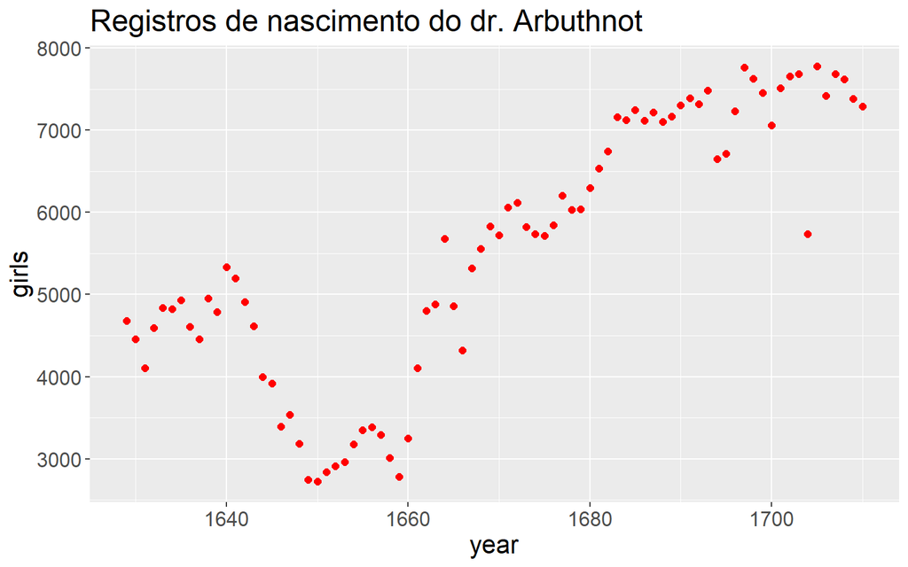

```r
arbuthnot %>%
  ggplot(aes(x = year, y = girls)) +
  geom_point(size = 2, col = "red") +
  labs(
    title = "Registros de nascimento do dr. Arbuthnot"
  ) +
  theme(text = element_text(size = 16))
```

Podemos também fazer um gráfico de linhas, ao invés de plotar os pontos dispersos:

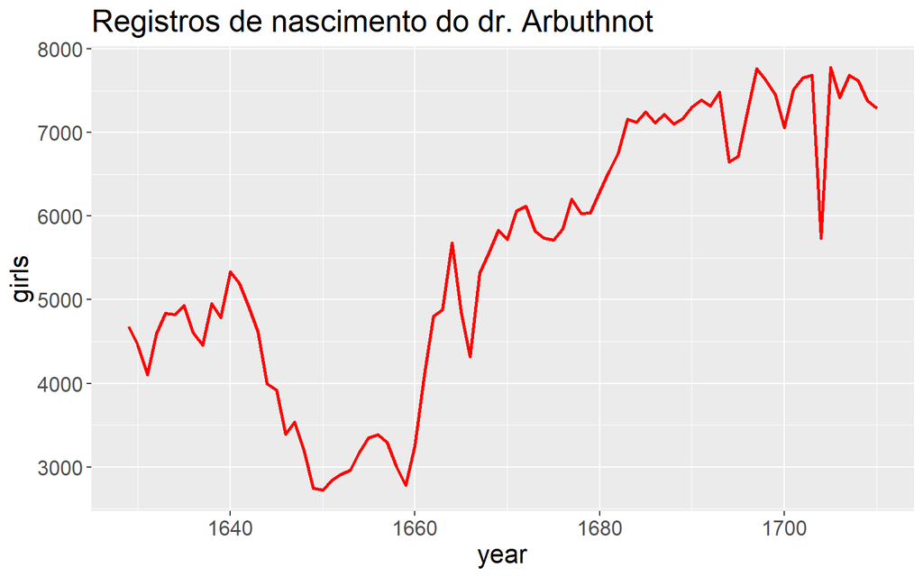

```r
arbuthnot %>%
  ggplot(aes(x = year, y = girls)) +
  geom_line(linewidth = 1, col = "red") +
  labs(
    title = "Registros de nascimento do dr. Arbuthnot"
  ) +
  theme(text = element_text(size = 16))
```

## Há alguma tendência aparente no número de meninas batizadas ao longo dos anos? Como você a descreveria?

Para saber o número total de crianças batizadas em cada ano, fazemos:

```r
arbuthnot$boys + arbuthnot$girls
```

```
##  [1]  9901  9315  8524  9584  9997  9855 10034  9522  9160 10311 10150 10850
## [13] 10670 10370  9410  8104  7966  7163  7332  6544  5825  5612  6071  6128
## [25]  6155  6620  7004  7050  6685  6170  5990  6971  8855 10019 10292 11722
## [37]  9972  8997 10938 11633 12335 11997 12510 12563 11895 11851 11775 12399
## [49] 12626 12601 12288 12847 13355 13653 14735 14702 14730 14694 14951 14588
## [61] 14771 15211 15054 14918 15159 13632 13976 14861 15829 16052 15363 14639
## [73] 15616 15687 15448 11851 16145 15369 16066 15862 15220 14928
```

Nesse caso, visualizamos um vetor com 82 entradas, cada uma contendo a soma do número de meninos e de meninas batizados no respectivo ano. Nós podemos ainda utilizar este vetor para gerar alguns gráficos, então iremos salvá-lo como uma coluna permanente do nosso banco de dados:

```r
arbuthnot = mutate(arbuthnot, total = boys + girls)

arbuthnot %>%
  head(10) %>%
  kable() %>%
  kable_styling(
    full_width = F,
    bootstrap_options = c("striped", "hover", "condensed",
                          "responsive")
    )
```

| year | boys | girls | total |
| --- | --- | --- | --- |
| 1629 | 5218 | 4683 | 9901 |
| 1630 | 4858 | 4457 | 9315 |
| 1631 | 4422 | 4102 | 8524 |
| 1632 | 4994 | 4590 | 9584 |
| 1633 | 5158 | 4839 | 9997 |
| 1634 | 5035 | 4820 | 9855 |
| 1635 | 5106 | 4928 | 10034 |
| 1636 | 4917 | 4605 | 9522 |
| 1637 | 4703 | 4457 | 9160 |
| 1638 | 5359 | 4952 | 10311 |

Assim, uma nova coluna chamada “total” foi incluída no banco de dados. Podemos criar um gráfico do número total de batismos por ano com o comando:

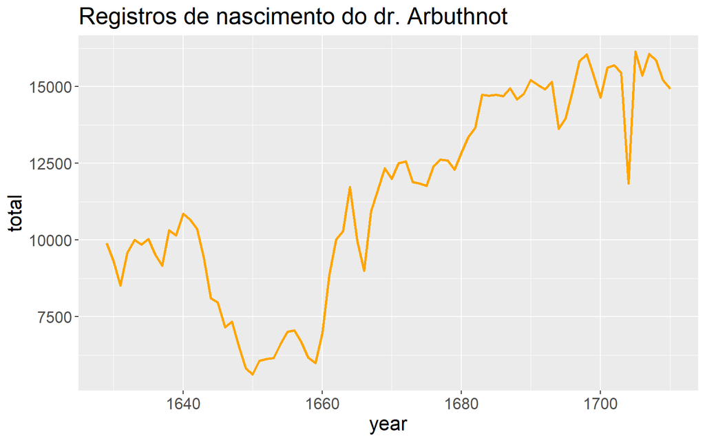

```r
arbuthnot %>%
  ggplot(aes(x = year, y = total)) +
  geom_line(linewidth = 1, col = "orange") +
  labs(
    title = "Registros de nascimento do dr. Arbuthnot"
  ) +
  theme(text = element_text(size = 16))
```

Podemos também calcular a proporção do número de meninos batizados em relação ao número de meninas batizadas em cada ano:

```r
arbuthnot$boys / arbuthnot$girls
```

```
##  [1] 1.114243 1.089971 1.078011 1.088017 1.065923 1.044606 1.036120 1.067752
##  [9] 1.055194 1.082189 1.121656 1.034884 1.051923 1.112016 1.038120 1.027521
## [17] 1.032661 1.109867 1.073529 1.057215 1.121267 1.061719 1.137676 1.107290
## [25] 1.080095 1.082416 1.091371 1.084565 1.032533 1.047793 1.153901 1.146905
## [33] 1.156075 1.085988 1.108584 1.063369 1.052697 1.083121 1.055242 1.092266
## [41] 1.116143 1.097744 1.064016 1.052778 1.043112 1.065354 1.059647 1.120575
## [49] 1.035467 1.088679 1.034100 1.039530 1.044237 1.024466 1.058536 1.062860
## [57] 1.032846 1.064054 1.072498 1.054359 1.060974 1.083128 1.036526 1.039092
## [65] 1.025792 1.050850 1.081931 1.055748 1.037981 1.104904 1.061594 1.073219
## [73] 1.078254 1.048981 1.010673 1.065354 1.075460 1.072132 1.090022 1.080808
## [81] 1.062331 1.048299
```

Podemos também calcular a proporção de meninos batizados ano a ano em relação ao total de crianças batizadas no respectivo ano:

```r
arbuthnot$boys / (arbuthnot$boys + arbuthnot$girls)
```

```
##  [1] 0.5270175 0.5215244 0.5187705 0.5210768 0.5159548 0.5109082 0.5088698
##  [8] 0.5163831 0.5134279 0.5197362 0.5286700 0.5085714 0.5126523 0.5265188
## [15] 0.5093518 0.5067868 0.5080341 0.5260366 0.5177305 0.5139059 0.5285837
## [22] 0.5149679 0.5322023 0.5254569 0.5192526 0.5197885 0.5218447 0.5202837
## [29] 0.5080030 0.5116694 0.5357262 0.5342132 0.5361942 0.5206108 0.5257482
## [36] 0.5153557 0.5128359 0.5199511 0.5134394 0.5220493 0.5274422 0.5232975
## [43] 0.5155076 0.5128552 0.5105507 0.5158214 0.5144798 0.5284297 0.5087122
## [50] 0.5212285 0.5083822 0.5096910 0.5108199 0.5060426 0.5142178 0.5152360
## [57] 0.5080788 0.5155165 0.5174905 0.5132301 0.5147925 0.5199527 0.5089677
## [64] 0.5095857 0.5063659 0.5123973 0.5196766 0.5135590 0.5093183 0.5249190
## [71] 0.5149385 0.5176583 0.5188268 0.5119526 0.5026541 0.5158214 0.5181790
## [78] 0.5174052 0.5215362 0.5194175 0.5151117 0.5117899
```

Vamos usar novamente a função `mutate`para incluir uma nova coluna em nosso conjunto de dados para a proporção do número de meninos em relação ao total de recém-nascidos em cada ano:

```r
arbuthnot = mutate(arbuthnot, ratio_boys = arbuthnot$boys / arbuthnot$total)

arbuthnot %>%
  head(10) %>%
  kable() %>%
  kable_styling(
    full_width = F,
    bootstrap_options = c("striped", "hover", "condensed",
                          "responsive")
    )
```

| year | boys | girls | total | ratio_boys |
| --- | --- | --- | --- | --- |
| 1629 | 5218 | 4683 | 9901 | 0.5270175 |
| 1630 | 4858 | 4457 | 9315 | 0.5215244 |
| 1631 | 4422 | 4102 | 8524 | 0.5187705 |
| 1632 | 4994 | 4590 | 9584 | 0.5210768 |
| 1633 | 5158 | 4839 | 9997 | 0.5159548 |
| 1634 | 5035 | 4820 | 9855 | 0.5109082 |
| 1635 | 5106 | 4928 | 10034 | 0.5088698 |
| 1636 | 4917 | 4605 | 9522 | 0.5163831 |
| 1637 | 4703 | 4457 | 9160 | 0.5134279 |
| 1638 | 5359 | 4952 | 10311 | 0.5197362 |

Podemos também fazer um gráfico da proporção de meninos batizados relativo ao total ano a ano:

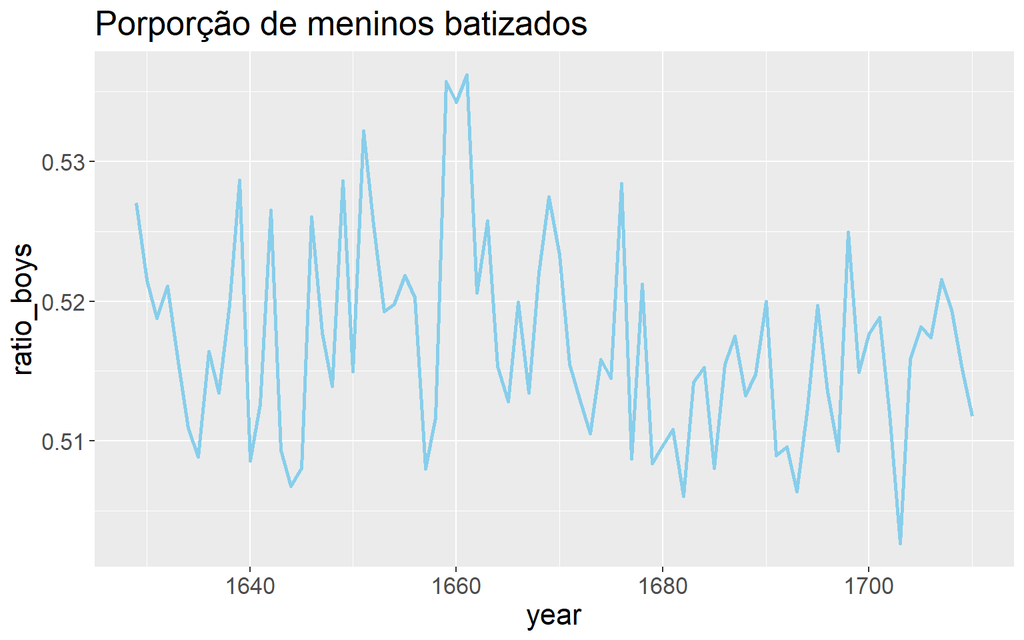

```r
arbuthnot %>%
  ggplot(aes(x = year, y = ratio_boys)) +
  geom_line(linewidth = 1, col = "skyblue") +
  labs(
    title = "Porporção de meninos batizados"
  ) +
  theme(text = element_text(size = 16))
```

Podemos ainda criar uma variável lógica que indica se o número de meninos nascidos é maior que o número de meninas:

```r
arbuthnot = mutate(arbuthnot, more_boys = boys > girls)

arbuthnot %>%
  head(10) %>%
  kable() %>%
  kable_styling(
    full_width = F,
    bootstrap_options = c("striped", "hover", "condensed",
                          "responsive")
    )
```

| year | boys | girls | total | ratio_boys | more_boys |
| --- | --- | --- | --- | --- | --- |
| 1629 | 5218 | 4683 | 9901 | 0.5270175 | TRUE |
| 1630 | 4858 | 4457 | 9315 | 0.5215244 | TRUE |
| 1631 | 4422 | 4102 | 8524 | 0.5187705 | TRUE |
| 1632 | 4994 | 4590 | 9584 | 0.5210768 | TRUE |
| 1633 | 5158 | 4839 | 9997 | 0.5159548 | TRUE |
| 1634 | 5035 | 4820 | 9855 | 0.5109082 | TRUE |
| 1635 | 5106 | 4928 | 10034 | 0.5088698 | TRUE |
| 1636 | 4917 | 4605 | 9522 | 0.5163831 | TRUE |
| 1637 | 4703 | 4457 | 9160 | 0.5134279 | TRUE |
| 1638 | 5359 | 4952 | 10311 | 0.5197362 | TRUE |

## Um novo conjunto de dados: registros atuais de nascimento nos Estados Unidos

Vamos agora trabalhar com um conjunto de dados obtido mais recentemente. Primeiro, carregamos o dataframe:

```r
source("http://www.openintro.org/stat/data/present.R")
```

1. Quais anos estão incluídos nesse conjuntos de dados?

```r
names(present)
```

```
## [1] "year"  "boys"  "girls"
```

```r
present$year
```

```
##  [1] 1940 1941 1942 1943 1944 1945 1946 1947 1948 1949 1950 1951 1952 1953 1954
## [16] 1955 1956 1957 1958 1959 1960 1961 1962 1963 1964 1965 1966 1967 1968 1969
## [31] 1970 1971 1972 1973 1974 1975 1976 1977 1978 1979 1980 1981 1982 1983 1984
## [46] 1985 1986 1987 1988 1989 1990 1991 1992 1993 1994 1995 1996 1997 1998 1999
## [61] 2000 2001 2002
```

Vemos então que os anos incluídos vão de 1940 a 2002.

2. Quais as dimensões da base de dados?

```r
dim(present)
```

```
## [1] 63  3
```

3. Quais sãos os nomes das colunas ou variáveis?

```r
names(present)
```

```
## [1] "year"  "boys"  "girls"
```

4. Como esses dados se comparam aos de Arbuthnot? Eles estão em uma escala similar?

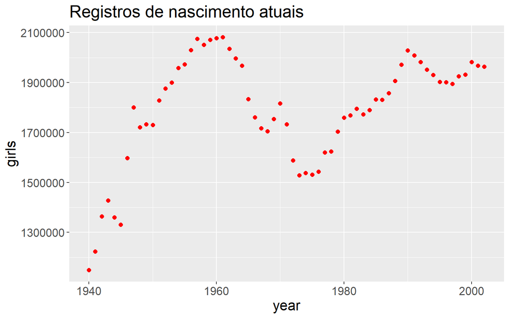

```r
present %>%
  ggplot(aes(x = year, y = girls)) +
  geom_point(size = 2, col = "red") +
  labs(
    title = "Registros de nascimento atuais"
  ) +
  theme(text = element_text(size = 16))
```

```r
cat("Intervalo de anos para os dados do dr. Arbuthnot:",
    c(min(arbuthnot$year), max(arbuthnot$year)),
    "\nIntervalo de anos para os dados atuais:",
    c(min(present$year), max(present$year))
    )
```

```
## Intervalo de anos para os dados do dr. Arbuthnot: 1629 1710
## Intervalo de anos para os dados atuais: 1940 2002
```

Como podemos ver a partir do resultado do gráfico acima, bem como com a saída da função `cat()`, os dados dos conjuntos `arbuthnot` e `present` estão em escalas diferentes. No caso dos dados do dr. Arbuthnot, o número de batismos de menina, por exemplo, está na escala de alguns milhares, ao passo que no conjunto de dados atual, esse número está na escala de milhão. Além disso, o intervalo temporal de coleta dos dois conjuntos de dados são também diferentes.

5. Crie um gráfico que mostre a proporção de meninos em relação às meninas para cada ano do conjunto de dados. O que você vê? A observação de Arbuthnot de que os meninos nascem numa proporção maior do que as meninas se mantém nos EUA?

```r
present = mutate(present, ratio_boys_girls = present$boys/present$girls)
```

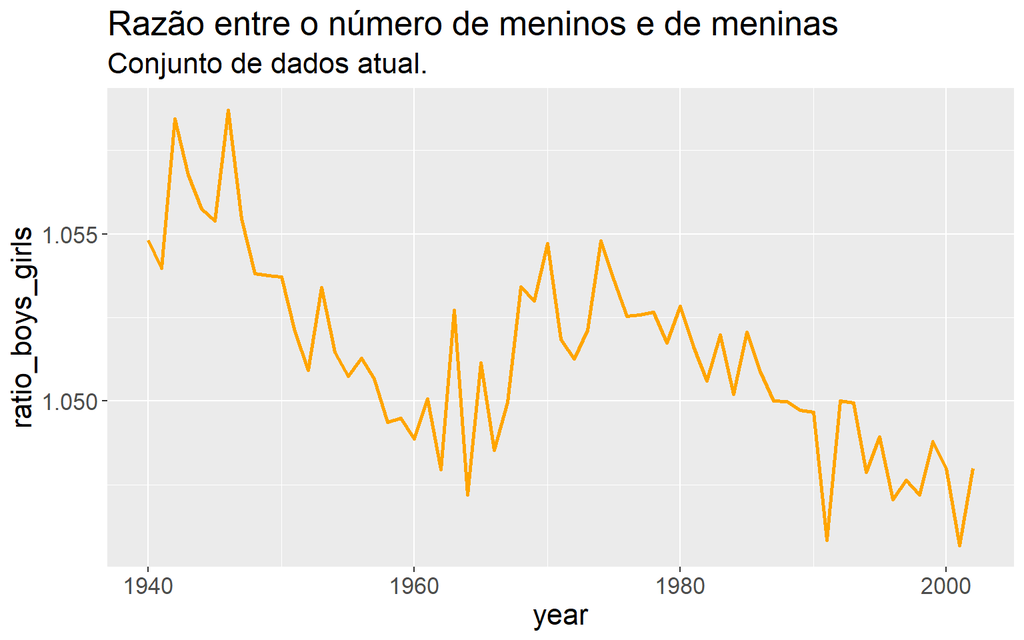

```r
present %>%
  ggplot(aes(x = year, y = ratio_boys_girls)) +
  geom_line(linewidth = 1, col = "orange") +
  labs(
    title = "Razão entre o número de meninos e de meninas",
    subtitle = "Conjunto de dados atual."
  ) +
  theme(text = element_text(size = 16))
```

```r
present$meninos > present$meninas
```

```
## logical(0)
```

Outra maneira de ver se existe algum ano no qual o número de meninos nascidos é menor do que o número de meninas é fazendo um filtro no dataframe:

```r
present[present$boys < present$girls, ]
```

```
## [1] year             boys             girls            ratio_boys_girls
## <0 linhas> (ou row.names de comprimento 0)
```

Como vemos, a saída é vazia, tendo apenas os nomes das variáveis, sem qualquer observação nas linhas.

6. Em qual ano se verifica o maior número de nascimentos nos EUA? **Dica**: primeiramente calcule o total e salve em uma nova variável. Então, ordene seu banco de dados em ordem decrescente na colula total. Você pode fazer isso interativamente no seu *Data Viewer*, clicando nas flechas próximas aos nomes das variáveis.

Primeiro, vamos acrescentar a coluna “Total” ao nosso dataframe.

```r
present = mutate(present, Total = present$boys + present$girls)
```

Em seguida, vamos aplicar um filtro ao dataframe, assim como fizemos acima, e mostrar todas as colunas do dataframe, porém apenas a linha correspondente ao valor máximo da coluna **Total**:

```r
present[present$Total == max(present$Total), ]
```

```
##    year    boys   girls ratio_boys_girls   Total
## 22 1961 2186274 2082052         1.050057 4268326
```

Uma maneira mais elegante de fazer esse filtro é por meio da função `subset()`:

```r
present%>%
  subset(Total == max(Total))
```

```
##    year    boys   girls ratio_boys_girls   Total
## 22 1961 2186274 2082052         1.050057 4268326
```

Por outro lado, para responder à mesma pergunta e mostrar apenas as colunas **ano** e **Total**, na linha correspondente ao total máximo, fazemos:

```r
present[present$Total == max(present$Total), c('year', 'Total')]
```

```
##    year   Total
## 22 1961 4268326
```

Ou, por meio da função `select()`:

```r
present%>%
  subset(Total == max(Total), select = c("year", "Total"))
```

```
##    year   Total
## 22 1961 4268326
```

Esses dados são provenientes de uma pesquisa realizada pelo Centro de Controle de Doenças (Center For Disease Control) [Link do Artigo](http://www.cdc.gov/nchs/data/nvsr/nvsr53/nvsr53_20.pdf).

# Lab02: Introdução à Análise de Dados

Algumas pessoas definem a Estatística como a ciência que tem por objetivo transformar informação em conhecimento. O primeiro passo no processo é sumarizar e descrever a informação bruta - os dados. Neste laboratório, você obterá novos conhecimentos sobre saúde pública gerando sumários gráficos e numéricos de um conjunto de dados coletados pelo Centro para o Controle e Prevenção de Doenças (Centers for Disease Control and Prevention, CDC). Como esse conjunto de dados é extenso, ao longo do caminho você também aprenderá as habilidades indispensáveis de processamento de dados e organização de subconjuntos.

## Conteúdos abordados neste laboratório

- Histogramas
- Estatísticas descritivas
- Tabelas de contingência
- Aprofundando a biblioteca `dplyr`
- Observando relações entre duas variáveis quantitativas
- Observando relações entre duas variáveis qualitativas
- Observando relações entre uma variável qualitativa e uma quantitativa
- Box plots
- Distribuição normal

## Carregamento e detalhamento dos dados

O Sistema de Monitoramento de Fatores de Risco Comportamental (Behavioral Risk Factor Surveillance System, BRFSS) é uma pesquisa anual realizada por telefone com 350.000 pessoas nos Estados Unidos. Como seu nome implica, o BRFSS foi desenvolvido para identificar fatores de risco na população adulta e relatar tendências emergentes na saúde. Por exemplo, os respondentes são indagados sobre sua dieta e atividades físicas semanais, seu diagnóstico de HIV/AIDS, uso provável de tabaco, e mesmo seu nível de cobertura por planos de saúde. O website do BRFSS http://www.cdc.gov/brfss contém uma descrição completa desta pesquisa, incluindo as questões que motivaram o estudo e muitos resultados interessantes derivados dos dados.

Nós focaremos em uma amostra aleatória de 20.000 pessoas do BRFSS conduzida em 2000. Ainda que existam mais de 200 variáveis neste conjunto de dados, nós trabalharemos com um subconjunto menor.

Começamos importando os dados das 20.000 observações para dentro do espaço de trabalho do R. Depois de inicializar o RStudio, entre com o seguinte comando:

```r
source("http://www.openintro.org/stat/data/cdc.R")
```

O conjunto de dados `cdc` que aparece em seu espaço de trabalho é uma matriz de dados, onde cada linha representa um caso e cada coluna representa uma `variável`. Lembre-se que o R denomina este formato de dados como banco de dados (data frame), que será um termo utilizado ao longo dos laboratórios.

Para visualizar o nome das variáveis, digite o comando:

```r
names(cdc)
```

```
## [1] "genhlth"  "exerany"  "hlthplan" "smoke100" "height"   "weight"   "wtdesire"
## [8] "age"      "gender"
```

Ainda, nosso banco de dados tem 20000 indivíduos entrevistados, sendo 10431 do gênero feminino.

Cada uma dessas variáveis corresponde a uma questão que foi feita na pesquisa. Por exemplo, para `genhlth`, os respondentes foram indagados sobre sua saúde geral, respondendo good, very good, excellent e fair. A variável `exerany` indica se o respondente se exercitou no último mês (1) ou não (0). Da mesma forma, `hlthplan` indica se o respondente tem alguma forma de cobertura por plano de saúde (1) ou não (0). A variável `smoke100` indica se o respondente fumou pelo menos 100 cigarros ao longo da vida. As variáveis `height`, `weight`, `wtdesire`, `age` e `gender` registram a altura (em polegadas), o peso (em libras), o peso desejado (em libras), a idade (em anos) e o gênero, respectivamente.

Em tese, você poderia verificar toda a base de dados de só uma vez digitando seu nome no console, mas isso pode não ser muito sábio neste caso. Sabemos que `cdc` tem 20.000 linhas, portanto verificar o conjunto de dados inteiro significa inundar sua tela. Uma função bastante útil para dar uma rápida olhada no seu conjunto de dados, ver suas dimensões e os tipos de dados é a função `str`:

```r
str(cdc)
```

```
## 'data.frame':    20000 obs. of  9 variables:
##  $ genhlth : Factor w/ 5 levels "excellent","very good",..: 3 3 3 3 2 2 2 2 3 3 ...
##  $ exerany : num  0 0 1 1 0 1 1 0 0 1 ...
##  $ hlthplan: num  1 1 1 1 1 1 1 1 1 1 ...
##  $ smoke100: num  0 1 1 0 0 0 0 0 1 0 ...
##  $ height  : num  70 64 60 66 61 64 71 67 65 70 ...
##  $ weight  : int  175 125 105 132 150 114 194 170 150 180 ...
##  $ wtdesire: int  175 115 105 124 130 114 185 160 130 170 ...
##  $ age     : int  77 33 49 42 55 55 31 45 27 44 ...
##  $ gender  : Factor w/ 2 levels "m","f": 1 2 2 2 2 2 1 1 2 1 ...
```

Note que o R chama as as variáveis categóricas de `factor` e a quantidade de categorias de `levels`. Você também poderá dar pequenas espiadas nos dados utilizando os comandos `head` (que mostra as primeiras linhas de dados). Vamos utilizar também a função `kable()`, do pacote `kableExtra`, a fim de deixar a tabela com um layout agradável:

```r
head(cdc) %>%
  kable() %>%
  kable_styling(
    full_width = F,
    bootstrap_options = c("striped", "hover", "condensed",
                          "responsive")
    )
```

| genhlth | exerany | hlthplan | smoke100 | height | weight | wtdesire | age | gender |
| --- | --- | --- | --- | --- | --- | --- | --- | --- |
| good | 0 | 1 | 0 | 70 | 175 | 175 | 77 | m |
| good | 0 | 1 | 1 | 64 | 125 | 115 | 33 | f |
| good | 1 | 1 | 1 | 60 | 105 | 105 | 49 | f |
| good | 1 | 1 | 0 | 66 | 132 | 124 | 42 | f |
| very good | 0 | 1 | 0 | 61 | 150 | 130 | 55 | f |
| very good | 1 | 1 | 0 | 64 | 114 | 114 | 55 | f |

`tail()` (que mostra as últimas linhas de dados):

```r
tail(cdc) %>%
  kable() %>%
  kable_styling(
    full_width = F,
    bootstrap_options = c("striped", "hover", "condensed",
                          "responsive")
    )
```

|  | genhlth | exerany | hlthplan | smoke100 | height | weight | wtdesire | age | gender |
| --- | --- | --- | --- | --- | --- | --- | --- | --- | --- |
| 19995 | good | 0 | 1 | 1 | 69 | 224 | 224 | 73 | m |
| 19996 | good | 1 | 1 | 0 | 66 | 215 | 140 | 23 | f |
| 19997 | excellent | 0 | 1 | 0 | 73 | 200 | 185 | 35 | m |
| 19998 | poor | 0 | 1 | 0 | 65 | 216 | 150 | 57 | f |
| 19999 | good | 1 | 1 | 0 | 67 | 165 | 165 | 81 | f |
| 20000 | good | 1 | 1 | 1 | 69 | 170 | 165 | 83 | m |

ou as técnicas de construção de subconjuntos que você aprenderá no decorrer do laboratório.

Por outro lado, se quisermos mostrar o banco de dados na saída do arquivo html como uma tabela estruturada, podemos usar a biblioteca `rmarkdown`:

```r
paged_table(cdc)
```

|  | genhlth | exerany | hlthplan | smoke100 | height | weight | wtdesire | age | gender |
| --- | --- | --- | --- | --- | --- | --- | --- | --- | --- |
| 1 | good | 0 | 1 | 0 | 70 | 175 | 175 | 77 | m |
| 2 | good | 0 | 1 | 1 | 64 | 125 | 115 | 33 | f |
| 3 | good | 1 | 1 | 1 | 60 | 105 | 105 | 49 | f |
| 4 | good | 1 | 1 | 0 | 66 | 132 | 124 | 42 | f |
| 5 | very good | 0 | 1 | 0 | 61 | 150 | 130 | 55 | f |
| 6 | very good | 1 | 1 | 0 | 64 | 114 | 114 | 55 | f |
| 7 | very good | 1 | 1 | 0 | 71 | 194 | 185 | 31 | m |
| 8 | very good | 0 | 1 | 0 | 67 | 170 | 160 | 45 | m |
| 9 | good | 0 | 1 | 1 | 65 | 150 | 130 | 27 | f |
| 10 | good | 1 | 1 | 0 | 70 | 180 | 170 | 44 | m |

[output cut: 9990 more lines]

Podemos também estruturar a tabela de saída por meio da biblioteca `kableExtra`, mudando o nome das colunas da maneira que achar conveniente:

```r
kable(head(cdc, 10), col.names = c("Saúde", "Atividade Física", "Plano de Saúde", "Fumou nos últimos 100 dias?", "Altura", "Peso", "Peso desejado", "Idade", "Gênero")) %>%
  kable_styling(full_width = F, bootstrap_options = c("striped", "hover", "condensed", "responsive"))
```

| Saúde | Atividade Física | Plano de Saúde | Fumou nos últimos 100 dias? | Altura | Peso | Peso desejado | Idade | Gênero |
| --- | --- | --- | --- | --- | --- | --- | --- | --- |
| good | 0 | 1 | 0 | 70 | 175 | 175 | 77 | m |
| good | 0 | 1 | 1 | 64 | 125 | 115 | 33 | f |
| good | 1 | 1 | 1 | 60 | 105 | 105 | 49 | f |
| good | 1 | 1 | 0 | 66 | 132 | 124 | 42 | f |
| very good | 0 | 1 | 0 | 61 | 150 | 130 | 55 | f |
| very good | 1 | 1 | 0 | 64 | 114 | 114 | 55 | f |
| very good | 1 | 1 | 0 | 71 | 194 | 185 | 31 | m |
| very good | 0 | 1 | 0 | 67 | 170 | 160 | 45 | m |
| good | 0 | 1 | 1 | 65 | 150 | 130 | 27 | f |
| good | 1 | 1 | 0 | 70 | 180 | 170 | 44 | m |

## Descrevendo Distribuições

### Histogramas

O questionário do BRFSS é um tesouro enorme de informações. Um primeiro passo útil em qualquer análise é destilar toda essa informação em algumas estatísticas sumárias e gráficos.

Vamos começar olhando alguns histogramas. Nós podemos criar um histograma da idade dos respondentes com o seguinte comando:

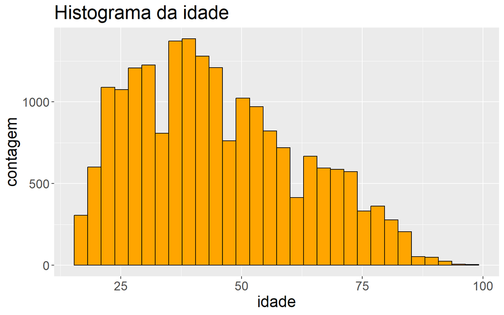

```r
cdc %>%
  ggplot(aes(x = age)) +
  geom_histogram(col = "black", fill = "orange") +
  labs(
    x = "idade",
    y = "contagem",
    title = "Histograma da idade"
  ) +
  theme(text = element_text(size = 18))
```

Esta função diz ao R para plotar a `age` no eixo-x. Além disso, a entrada `geom_histogram` (abreviação para geometric object) diz ao R o tipo de gráfico a ser plotado.

Histogramas costumam ser uma boa maneira de enxergar a forma da distribuição de uma variável, mas esta forma pode variar dependendo do número de intervalos escolhido (ou a amplitude de cada intervalo) para representar cada barra do histograma. Você pode definir facilmente a amplitude de cada intervalo ao indicá-lo ao R por meio do argumento `binwidth`:

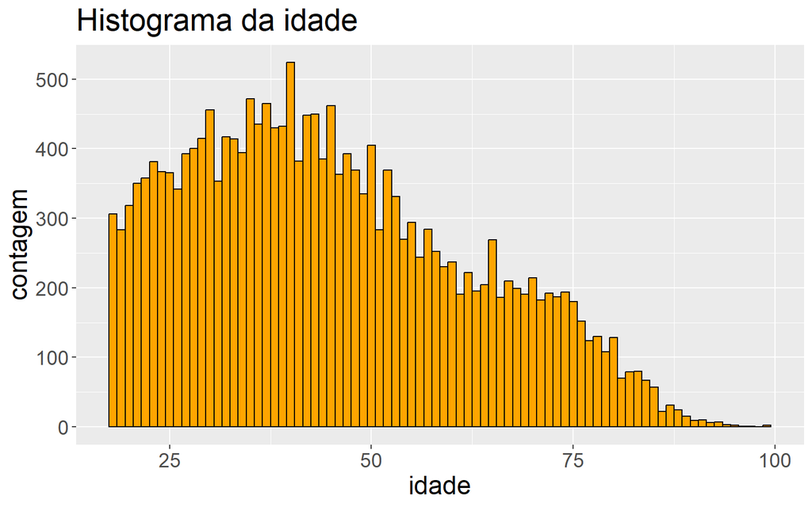

```r
cdc %>%
  ggplot(aes(x = age)) +
  geom_histogram(col = "black", fill = "orange", binwidth = 1) +
  labs(
    x = "idade",
    y = "contagem",
    title = "Histograma da idade"
  ) +
  theme(text = element_text(size = 18))
```

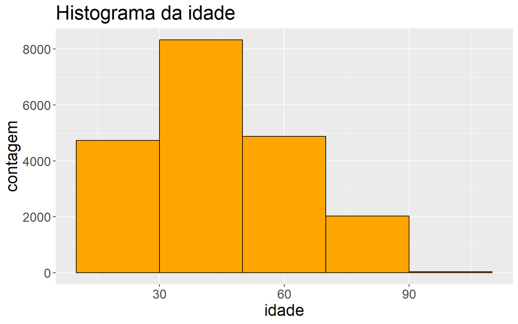

```r
cdc %>%
  ggplot(aes(x = age)) +
  geom_histogram(col = "black", fill = "orange", binwidth = 20) +
  labs(
    x = "idade",
    y = "contagem",
    title = "Histograma da idade"
  ) +
  theme(text = element_text(size = 18))
```

É uma boa ideia explicitar em seu código todas as opções ao invés de aceitar as entradas padrões do R. Isso lhe permitirá a construção de gráficos mais informacionais e esteticamente mais agradáveis.

Além disso, podemos adicionar transparência ao gráfico por meio do argumento `alpha`, assim como também podemos escolher o número de classes através do argumento `bins` abaixo:

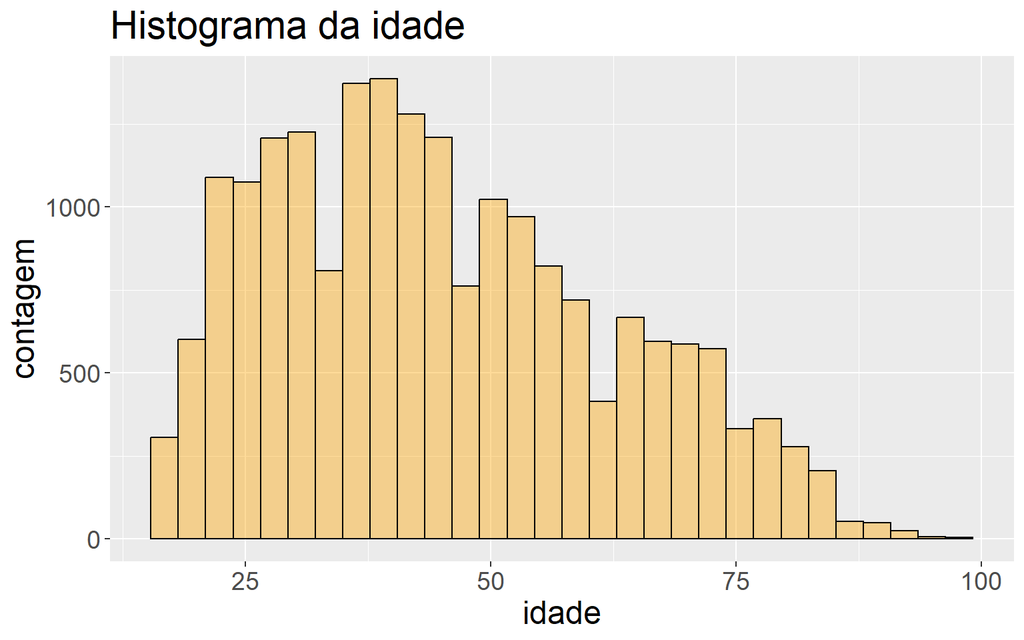

```r
cdc %>%
  ggplot(aes(x = age)) +
  geom_histogram(col = "black", fill = "orange", alpha = .4, bins = 30) +
  labs(
    x = "idade",
    y = "contagem",
    title = "Histograma da idade"
  ) +
  theme(text = element_text(size = 18))
```

Existem diversas possibilidades para alterar a estética dos seus gráficos e, para tal, nós o incentivamos a procurar informações à respeito dos comandos do R, assim como do pacote ggplot2. Por fim, é bastante comum que queiramos construir um histograma onde o eixo-y contenha uma medida de altura adequada, de tal modo que a área de cada bloco seja correspondente à frequência relativa do intervalo que representa a base do bloco, ao invés do número de observações. Neste caso, não podemos nos basear no formato do comando qplot, mas o pacote ggplot2 nos oferece alternativas interessantes e podemos obter esse gráfico com o comando abaixo:

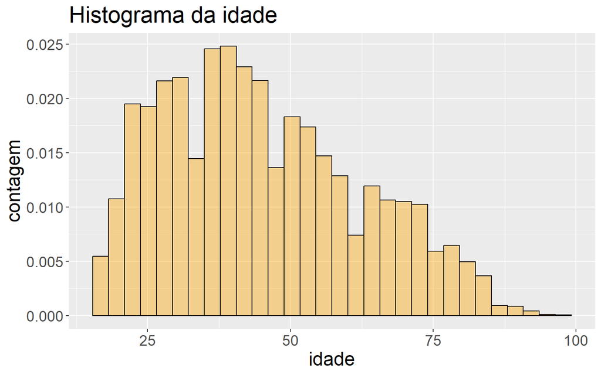

```r
cdc %>%
  ggplot(aes(x = age)) +
  geom_histogram(
    aes(y = after_stat(density)),
    col = "black",
    fill = "orange",
    alpha = .4,
    bins = 30
    ) +
  labs(
    x = "idade",
    y = "contagem",
    title = "Histograma da idade"
  ) +
  theme(text = element_text(size = 18))
```

Em todos os casos acima, `aes` indica ao R quais as variáveis correspondentes a cada eixo, `geom_histogram` indica ao R a geometria do histograma (no caso, escolhemos a densidade para o eixo-y) e as demais entradas são bastante similares às que comentamos nos gráficos anteriores. O comando + indica ao R que ao gráfico serão adicionadas novas informações adiante. Poderíamos, inclusive, adicionar uma linha com a densidade estimada ao último gráfico com o comando abaixo:

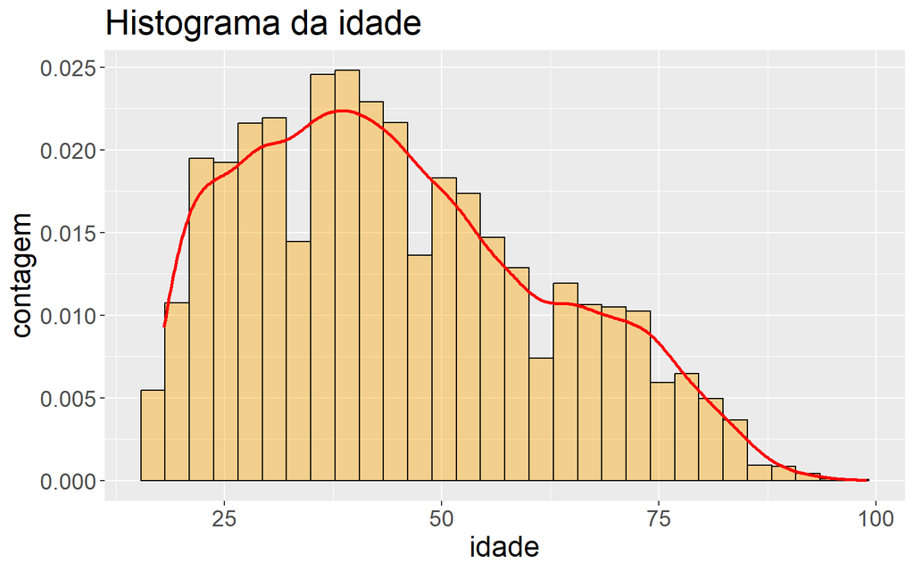

```r
cdc %>%
  ggplot(aes(x = age)) +
  geom_histogram(
    aes(y = after_stat(density)),
    col = "black",
    fill = "orange",
    alpha = .4,
    bins = 30
    ) +
  geom_density(
    col = "red",
    linewidth = 1
    ) +
  labs(
    x = "idade",
    y = "contagem",
    title = "Histograma da idade"
  ) +
  theme(text = element_text(size = 18))
```

### Estatísticas Descritivas

Como um exemplo simples, a função `summary` retorna um sumário numérico: mínimo, primeiro quartil, mediana, média, terceiro quartil e máximo. Para a variável `peso`do nosso conjunto de dados `cdc`, este sumário é dado por:

```r
cdc %>%
  select(weight) %>%
  summary()
```

```
##      weight
##  Min.   : 68.0
##  1st Qu.:140.0
##  Median :165.0
##  Mean   :169.7
##  3rd Qu.:190.0
##  Max.   :500.0
```

Alternativamente, poderíamos ter a mesma saída acima com o seguinte comando:

```r
summary(cdc$weight)
```

```
##    Min. 1st Qu.  Median    Mean 3rd Qu.    Max.
##    68.0   140.0   165.0   169.7   190.0   500.0
```

> O operador %>% é chamado de operedor de direcionamento. Basicamente, ele pega a saída da linha corrente e a direciona à linha de código seguinte.

Você também pode criar a sua própria lista de estatísticas descritivas escolhendo aquelas que te interessam, assim como as variáveis que deseja visualizar usando a função `summarise`:

```r
summarise(
  cdc,
  media_pe = mean(weight),
  dp_pe = sd(weight),
  media_alt = mean(height),
  dp_alt = sd(height)
  ) %>%
  kable() %>%
  kable_styling(
    full_width = F,
    bootstrap_options = c("striped", "hover", "condensed",
                          "responsive")
    )
```

| media_pe | dp_pe | media_alt | dp_alt |
| --- | --- | --- | --- |
| 169.683 | 40.08097 | 67.1829 | 4.125954 |

ou calcular uma estatística descritiva individualmente com o comando

```r
mean(cdc$weight)
```

```
## [1] 169.683
```

```r
median(cdc$height)
```

```
## [1] 67
```

Note que na função `summarise` nós criamos uma lista de quatro elementos. Os nomes desses elementos são definidos pelo usuário, por exemplo `mean_pe`, `dp_pe`, etc. e você pode alterá-los como quiser (apenas não utilize espaço entre seus nomes). Ao calcular estas estatísticas, o R também exige que você conheça as chamadas das funções. Algumas chamadas úteis para estatísticas descritivas numéricas únicas seguem abaixo com seu significado:

- `mean` - calcula a média
- `median` - calcula a mediana
- `sd` - calcula o desvio padrão amostral
- `var` - calcula a variância amostral
- `IQR` - calcula a distância interquantil
- `range` - calcula o mínimo e o máximo
- `min` - calcula o mínimo
- `max` - calcula o máximo

Uma outra funcionalidade bastante útil é você ser capaz de calcular estatísticas descritivas para várias categorias no seu banco de dados. Por exemplo, nós podemos calcular as estatísticas desejadas separadamente para os grupos masculino e feminino usando a função `group_by`:

```r
cdc %>%
  group_by(gender) %>%
  summarise(
    media_pe = mean(weight),
    dp_pe = sd(weight),
    media_al = mean(height),
    dp_al = sd(height)
    ) %>%
  kable() %>%
  kable_styling(
    full_width = F,
    bootstrap_options = c("striped", "hover", "condensed",
                          "responsive")
    )
```

| gender | media_pe | dp_pe | media_al | dp_al |
| --- | --- | --- | --- | --- |
| m | 189.3227 | 36.55036 | 70.25165 | 3.009219 |
| f | 151.6662 | 34.29752 | 64.36775 | 2.787304 |

Aqui, primeiramente agrupamos os dados por gênero, e depois calculamos as estatísticas descritivas.

- Exercício 2: Calcule a mediana e a distância interquantil da variável `peso`, separadamente, para pessoas que se exercitaram ou não no último mês.

```r
cdc %>%
  group_by(exerany) %>%
  summarise(
    median_pe = median(weight),
    dq_peso = IQR(weight)
    ) %>%
  kable() %>%
     kable_styling(
    full_width = F,
    bootstrap_options = c("striped", "hover", "condensed",
                          "responsive")
    )
```

| exerany | median_pe | dq_peso |
| --- | --- | --- |
| 0 | 165 | 55 |
| 1 | 165 | 50 |

### Tabelas

Ainda que faça sentido descrever uma variável quantitativa como `peso` em termos destas estatísticas, o que fazer com variáveis qualitativas? Nós podemos considerar a frequência da amostra ou a distribuição relativa de frequência. A função `table` faz isso por você contando o número de vezes que cada tipo de resposta é dada. Por exemplo, para ver o número de pessoas que fumaram 100 cigarros ao longo de sua vida, digite

```r
cdc %>%
  select(smoke100) %>%
  table()
```

```
## smoke100
##     0     1
## 10559  9441
```

ou então, verifique a distribuição da frequência relativa digitando

```r
cdc %>%
  select(smoke100) %>%
  table()/20000
```

```
## smoke100
##       0       1
## 0.52795 0.47205
```

Perceba como o R automaticamente divide todas as entradas na tabela por 20.000 no comando acima. Isso é similar a algo que observamos no último laboratório; quando multiplicamos ou dividimos um vetor por um número, o R aplica essa ação a todas as entradas dos vetores. Como vimos acima, isso também funciona para tabelas.

A seguir, criamos um gráfico de barras para as entradas na tabela:

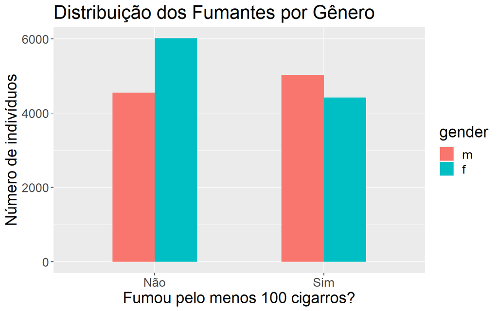

```r
cdc %>%
  select(smoke100, gender) %>%
  mutate(smoke100 = ifelse(smoke100 == 1, "Sim", "Não")) %>%
  ggplot(aes(x = smoke100, fill = gender)) +
  geom_bar(position = "dodge", width = 0.5) +
  labs(
    x = "Fumou pelo menos 100 cigarros?",
    y = "Número de indivíduos",
    title = "Distribuição dos Fumantes por Gênero"
  ) +
  theme(text = element_text(size = 18))
```

- Calcule a distribuição da frequência relativa para as variáveis `gender` e `genhlth`. Quantos homens compõem a amostra? Qual proporção da amostra diz estar com saúde excelente?

Para a variável `gender` temos, em relação ao total:

```r
cdc %>%
  select(gender) %>%
  table() %>%
  prop.table()
```

```
## gender
##       m       f
## 0.47845 0.52155
```

Já para a variável `genhlth`, temos:

```r
cdc %>%
  select(genhlth) %>%
  table() %>%
  prop.table()
```

```
## genhlth
## excellent very good      good      fair      poor
##   0.23285   0.34860   0.28375   0.10095   0.03385
```

O comando `table` pode também ser utilizado para criar tabelas de contingência. Por exemplo, para examinar quais participantes fumaram separadamente por gênero, podemos usar os comandos abaixo.

```r
cdc %>%
  select(gender, smoke100) %>%
  table()
```

```
##       smoke100
## gender    0    1
##      m 4547 5022
##      f 6012 4419
```

1. Qual percentual de fumantes são homens? Qual percentual de fumantes são mulheres?

Para responder essa pergunta, da forma como dispusemos os dados, precisamos determinar o percentual em relação ao total da coluna:

```r
cdc %>%
  select(gender, smoke100) %>%
  table() %>%
  prop.table(margin = 2)
```

```
##       smoke100
## gender         0         1
##      m 0.4306279 0.5319352
##      f 0.5693721 0.4680648
```

Nesse caso, vemos que aproximadamente 53% dos fumantes são homens e aproximadamente 47% são mulheres. Poderíamos também estar interessados em determinar os percentuais em relação ao total geral de indivíduos na amostra:

```r
cdc %>%
  select(gender, smoke100) %>%
  table() %>%
  prop.table()
```

```
##       smoke100
## gender       0       1
##      m 0.22735 0.25110
##      f 0.30060 0.22095
```

Poderíamos fazer o mesmo procedimento apenas com filtros no dataframe, sem usar a função `table()`. Por exemplo, para determinar o percentual de fumantes que são mulheres, fazemos:

```r
nrow( cdc[cdc$smoke100 == 1 & cdc$gender == 'f', ] ) / nrow( cdc[cdc$smoke100 == 1, ] )
```

```
## [1] 0.4680648
```

2. Dentre os homens, qual o percentual dos que são fumantes? Dentre as mulheres, qual o percentual das que são fumantes?

Para responder a essa pergunta, da forma como dispusemos os dados, precisamos determinar o percentual em relação ao total da linha:

```r
cdc %>%
  select(gender, smoke100) %>%
  table() %>%
  prop.table(margin = 1)
```

```
##       smoke100
## gender         0         1
##      m 0.4751803 0.5248197
##      f 0.5763589 0.4236411
```

Nesse caso, vemos que o percentual de homens que são fumantes é aproximandamente 52%, enquanto nas mulheres esse percentual é de aproximadamente 42%.

3. Qual par de estatísticas é mais útil para determinar se é mais provável um homem ou uma mulher ser fumante? Justifique sua resposta.

Penso que, nesse caso, o melhor par de estatísticas para estimar se é mais provável um homem ou uma mulher ser fumante é aquele calculado no item 1, ou seja, dentre os fumantes, qual o percentual de homens e de mulheres.

- **Indo um pouco além:** uma outra maneira de olhar para essas tabelas de contingência é olhar para os totais (e não percentuais) em cada linha ou coluna. Isso pode ser feito com o uso da função `margin.table()`, da seguinte forma:
1. Somando sobre a linha:

```r
cdc %>%
  select(gender, smoke100) %>%
  table() %>%
  margin.table(margin = 1)
```

```
## gender
##     m     f
##  9569 10431
```

Nesse caso, a saída está nos retornando o número total de mulheres e de homens no conjunto de dados.

2. Somando sobre a coluna:

```r
cdc %>%
  select(gender, smoke100) %>%
  table() %>%
  margin.table(margin = 2)
```

```
## smoke100
##     0     1
## 10559  9441
```

Já aqui, como a soma está sendo feita ao longo da coluna, a saída está nos fornecendo o total de fumantes e de não fumantes.

## Visualizando Relações

### Entre duas variáveis quantitativas

No último laboratório nós visualizamos a relação entre duas variáveis numéricas usando gráficos de dispersão. Como um rápido lembrete, vamos criar mais um desses gráficos:

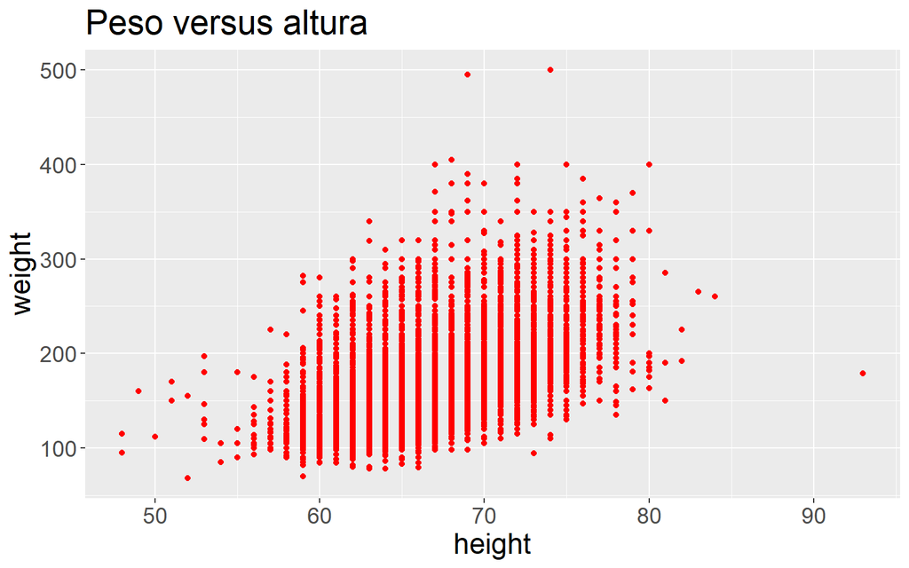

```r
cdc %>%
  ggplot(aes(x = height, y = weight)) +
  geom_point(size = 1.5, color = "red") +
  labs(
    title = "Peso versus altura"
  ) +
  theme(text = element_text(size = 18))
```

Uma medida importante que nos dá informação de como duas variáveis numéricas estão relacionadas é a correlação. Podemos calcular a correlação entre duas variáveis numéricas por meio do comando `cor`. Abaixo calculamos a correlação entre as variáveis peso e altura:

```r
cor(cdc$weight, cdc$height)
```

```
## [1] 0.5553222
```

- Com base no gráfico de dispersão e na medida de correlação, como você explica a relação entre essas variáveis?

### Entre duas variáveis qualitativas

Para criar um gráfico de barras segmentado nós podemos utilizar a seguinte opção.

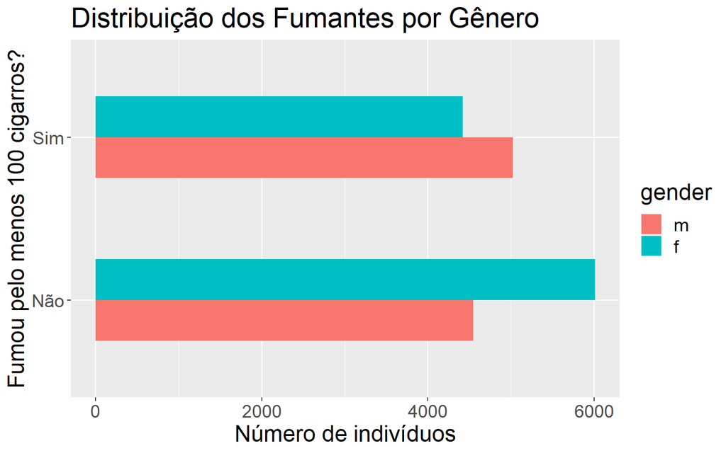

```r
cdc %>%
  select(smoke100, gender) %>%
  mutate(smoke100 = ifelse(smoke100 == 1, "Sim", "Não")) %>%
  ggplot(aes(x = smoke100, fill = gender)) +
  geom_bar(position = "dodge", width = 0.5) +
  coord_flip() +
  labs(
    x = "Fumou pelo menos 100 cigarros?",
    y = "Número de indivíduos",
    title = "Distribuição dos Fumantes por Gênero"
  ) +
  theme(text = element_text(size = 18))
```

### Entre uma variável quantitativa e uma qualitativa

A finalidade de um boxplot é proporcionar um esboço de uma variável com o propósito de comparar as categorias existentes. Portanto, podemos, por exemplo, comparar as alturas de homens e mulheres com

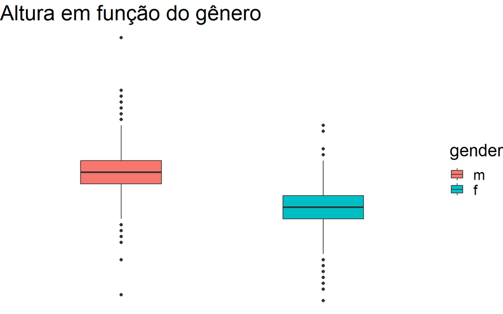

```r
cdc %>%
  ggplot(aes(x = gender, y = height, fill = gender)) +
  geom_boxplot(width = 0.4) +
  labs(
    x = "",
    title = "Altura em função do gênero"
  ) +
  theme_void() +
  theme(text = element_text(size = 20))
```

Há uma nova notação para a geometria aqui. Nós pedimos ao R para plotar os boxplots da altura em relação aos gêneros masculino e feminino que estão descritos no banco de dados.

Vamos considerar uma nova variável que não aparece diretamente neste conjunto de dados: o Índice de Massa Corporal (IMC) (https://pt.wikipedia.org/wiki/%C3%8Dndice_de_massa_corporal).

O IMC é uma razão entre peso e altura calculado segundo a fórmula:

$$IMC = \dfrac{peso}{altura^2}$$

Como nossos dados não estão nas unidades métricas (quilogramas e metros) e sim nas unidades imperiais (libras e polegadas) multiplicamos a primeira fórmula por 703 (que é o valor aproximado de conversão das unidades métricas para imperiais), obtendo a fórmula

$$IMC = \dfrac{peso}{altura^2}*703$$

Agora, podemos usar a função `mutate` para adicionar uma nova variável, relativa ao IMC, ao conjunto de dados `cdc`:

```r
cdc = mutate(cdc, imc = (weight/height^2)*703)
```

Perceba que a primeira linha acima representa uma simples aritmética, mas é aplicada para todos os 20.000 elementos do conjunto de dados `cdc`. Ou seja, para cada um dos 20.000 participantes, pegamos seu peso, dividimos pelo quadrado de sua altura e multiplicamos por 703. O resultado são 20.000 valores de IMC, um para cada respondente. Essa é uma das razões pela qual gostamos do R: ele nos permite realizar cálculos como esse utilizando expressões bem simples.

Agora nós podemos utilizar esta nova variável em nossa análise. Por exemplo, vamos criar uma sequência de boxplots da variável `imc` à partir das categorias da variável `saude`.

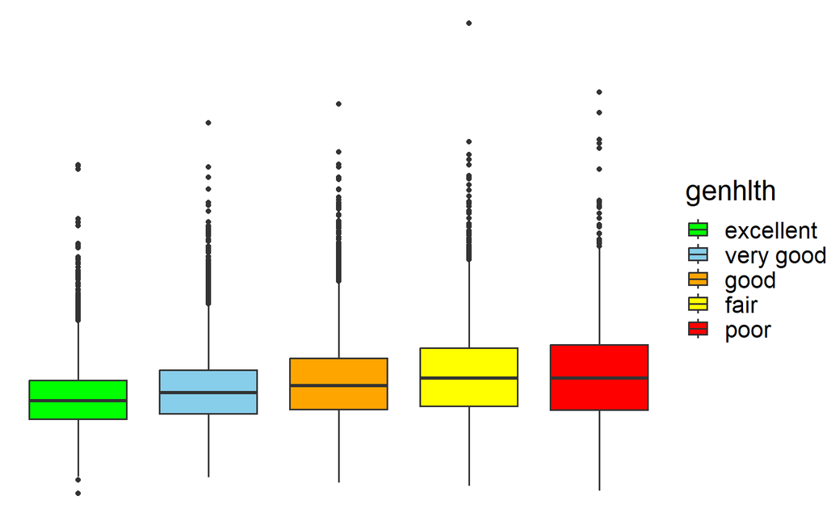

```r
cdc %>%
  ggplot(aes(x = genhlth, y = imc, fill = genhlth)) +
  geom_boxplot(size = 0.6) +
  theme_void() +
  scale_fill_manual(values = c("green", "skyblue", "orange", "yellow", "red")) +
  theme(text = element_text(size = 20))
```

- Essa figura nos mostra que, quanto pior o estado de saúde relatado da pessoa, maior é o seu IMC mediano.
- Escolha outra variável qualitativa do banco de dados e verifique como ela se relaciona ao IMC. Liste a variável que você escolheu, explique por que você pensou que ela poderia ter alguma relação com o IMC, construa uma sequência de boxplots à partir das categorias da variável e indique o que o gráfico parece sugerir.

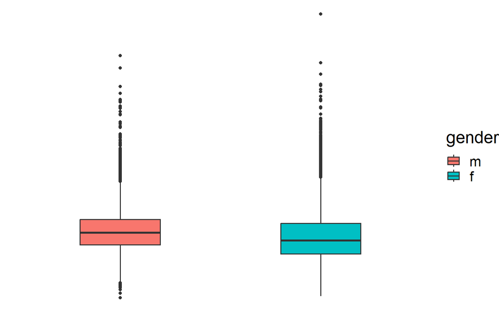

```r
cdc %>%
  ggplot(aes(x = gender, y = imc, fill = gender)) +
  geom_boxplot(size = 0.6, width = 0.4) +
  theme_void() +
  theme(text = element_text(size = 20))
```

Esperamos que o IMC médio (ou mediano) varie entre os gêneros, por isso escolhemos essa variável para analisar o comportamento dessa medida nos dois grupos disponíveis. Conforme vemos no boxplot acima, os homens possuem um IMC maior. Contudo, as mulheres possuem outliers mais acentuados.

## Subconjuntos

É bastante comum agruparmos em subconjuntos elementos individuais do banco de dados que possuam características específicas. Nós podemos fazer isso facilmente por meio da função `filter` e uma série de operadores lógicos. Os operadores lógicos mais comuns na análise de dados são

- `==` - significa “igual a”
- `!=` - significa “diferente de”
- `>` or `<` - significa “maior que” ou “menor que”
- `>=` or `<=` - siginifica “maior ou igual que” ou “menor ou igual que”

Usando esses operadores, nós podemos criar um subconjunto do banco de dados `cdc` relativo apenas aos homens e, então, salvar esta filtragem em um novo conjunto de dados chamado `homens`:

```r
men = filter(cdc, gender == "m")
```

Aqui nós criamos um novo objeto, chamado `men`. Nós podemos dar uma olhada neste objeto clicando sobre o banco de dados `homens` que aparece em seu ambiente de traballho (Environment), ou podemos usar o comando `head` para dar uma espiada nas suas primeiras linhas:

```r
head(men) %>%
  kable() %>%
  kable_styling(
    full_width = F,
    bootstrap_options = c("striped", "hover", "condensed",
                          "responsive")
    )
```

|  | genhlth | exerany | hlthplan | smoke100 | height | weight | wtdesire | age | gender | imc |
| --- | --- | --- | --- | --- | --- | --- | --- | --- | --- | --- |
| 1 | good | 0 | 1 | 0 | 70 | 175 | 175 | 77 | m | 25.10714 |
| 7 | very good | 1 | 1 | 0 | 71 | 194 | 185 | 31 | m | 27.05455 |
| 8 | very good | 0 | 1 | 0 | 67 | 170 | 160 | 45 | m | 26.62286 |
| 10 | good | 1 | 1 | 0 | 70 | 180 | 170 | 44 | m | 25.82449 |
| 11 | excellent | 1 | 1 | 1 | 69 | 186 | 175 | 46 | m | 27.46440 |
| 12 | fair | 1 | 1 | 1 | 69 | 168 | 148 | 62 | m | 24.80655 |

Este novo conjunto de dados contém as mesmas variáveis de antes, apenas com um número menor de linhas. Nós também poderíamos dizer ao R para manter algumas variáveis específicas usando a função `select` que foi introduzida anteriormente, mas isto não é relevante no momento, uma vez que iremos focar na criação de subconjuntos do banco de dados.

```r
men2 = cdc %>%
  subset(gender == "m", select = c(gender, genhlth, age))
```

Você poderá utilizar diversas dessas condições conjuntamente aos condicionadores `&` and `|`. O condicionador `&` corresponde à intersecção. A grosso modo, podemos dizer que `&` é equivalente a `e`. Nos comandos abaixo, agrupamos em um banco de dados os indivíduos que são homens e possuem mais de trinta anos:

```r
homens_e_30mais = filter(cdc, gender == "m" & age > 30)
```

Já o condicionador `|` corresponde à união e, podemos dizer, que é equivalente a `ou`. O comando abaixo agrupa os indivíduos do conjunto de dados que são homens ou possuam mais de 30 anos:

```r
homens_ou_30mais = filter(cdc, gender == "m" | age > 30)
```

À princípio, você pode usar esses condicionadores na quantidade e da maneira que decidir para formar subconjuntos. Se estes agrupamentos tem interpretações práticas é uma outra questão

- Crie um novo objeto `menos23_fumante` relativo àqueles que possuem menos de 23 anos e já fumaram 100 cigarros em seu tempo de vida. Escreva o comando que você utilizou para criar este novo objeto e apresente o número de casos que atendem a esse critério.

```r
menos23_fumante = filter(cdc, age < 23 & smoke100 == 1)
```

Vemos então que 620 indivíduos do nosso banco de dados atendem à condição de ter menos que 23 anos e já ter fumado pelos menos 100 cigarros ao longo da vida.

## Recapitulando

A esta altura, fizemos uma boa primeira exposição sobre a análise das informações contidas no questionário BRFSS. Nós descobrimos uma associação interessante entre fumo e gênero, e nós podemos comentar algo a respeito da relação entre a avaliação de saúde em geral dada pelas pessoas e seu próprio IMC. Nós também nos apropriamos de ferramentas computacionais essenciais – estatísticas descritivas, subconjuntos e gráficos – que nos servirão bem ao longo deste curso.

## Por sua conta

1. Crie um gráfico de dispersão da variável peso em relação ao peso desejado. Descreva a relação entre essas duas variáveis.

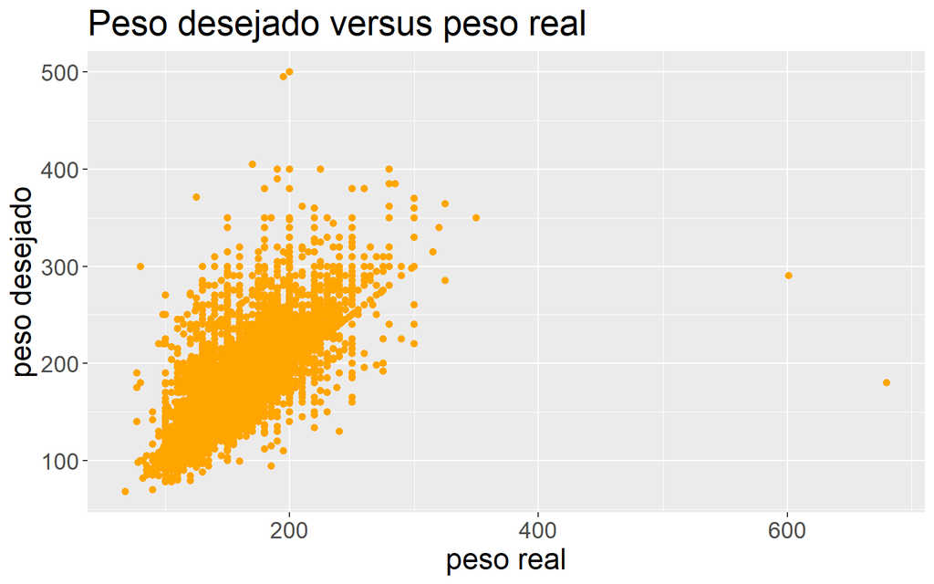

```r
cdc %>%
  ggplot(aes(x = wtdesire, y = weight)) +
  geom_point(size = 1.8, color = "orange") +
  labs(
    title = "Peso desejado versus peso real",
    x = "peso real",
    y = "peso desejado"
  ) +
  theme(text = element_text(size = 18))
```

```r
cor(cdc$wtdesire, cdc$weight)
```

```
## [1] 0.8000521
```

O gráfico de dispersão mostrado acima mostra uma relação praticamente linear entre as variáveis `weight` e `wtdesire`. Este fato é corroborado pelo coeficiente de correlação linear entre as variáveis, que foi de aproximadamente 0.8.

2. Vamos considerar uma nova variável: a diferença entre o peso desejado (`wtdesire`) e o peso atual (`weight`). Crie esta nova variável subtraindo as duas colunas na base de dados e atribuindo-as a um novo objeto chamado `pdif`.

```r
pdif = cdc$wtdesire - cdc$weight
```

3. Que tipo de dados estão contidos na variável `pdif`? Se uma observação de pdif é 0, o que isso implica em relação ao peso atual e desejado de uma pessoa? E se o valor de pdif for positivo ou negativo?

```r
typeof(pdif)
```

```
## [1] "integer"
```

```r
typeof(cdc$weight)
```

```
## [1] "integer"
```

```r
typeof(cdc$wtdesire)
```

```
## [1] "integer"
```

Vemos ainda que, se `pdif` é zero, a pessoa já acredita que está em seu peso ideal, desejado. Se essa quantidade é positiva, ela acredita que seu peso precisa aumentar e, se é negativa, ela acredita que precisa perder peso.

4. Descreva a distribuição de `pdif` em termos de sua posição central, forma e variação, incluindo qualquer gráfico que você usar. O que isso nos diz sobre como as pessoas se sentem a respeito do seu peso atual?

```r
cdc = mutate(cdc, pdif = wtdesire - weight)
```

```r
cdc %>%
  select(pdif) %>%
  summary()
```

```
##       pdif
##  Min.   :-300.00
##  1st Qu.: -21.00
##  Median : -10.00
##  Mean   : -14.59
##  3rd Qu.:   0.00
##  Max.   : 500.00
```

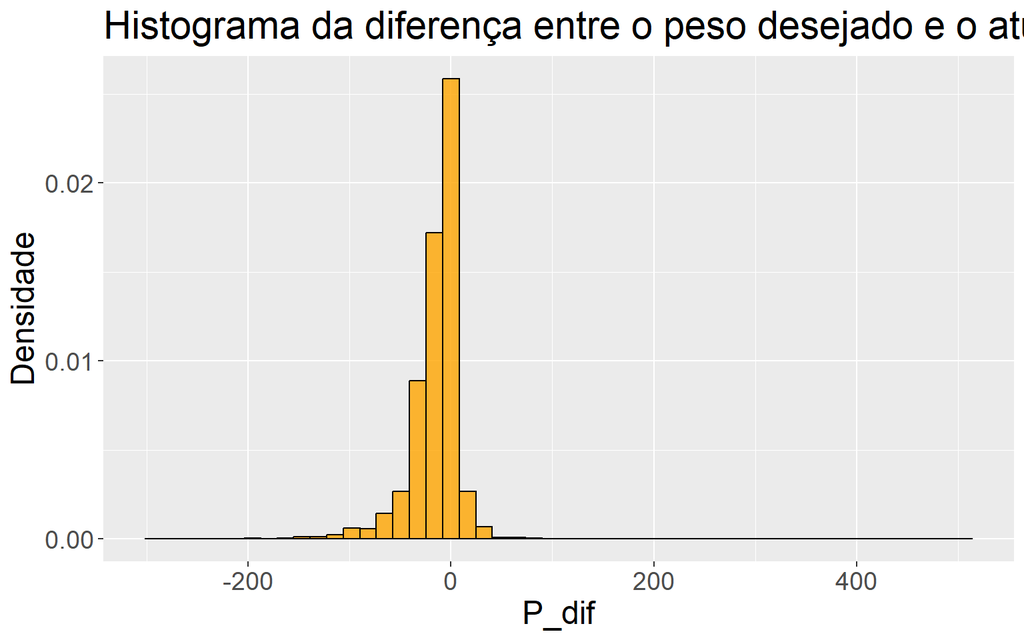

```r
cdc %>%
  ggplot(aes(x = pdif)) +
  geom_histogram(aes(y = after_stat(density)),
                 fill = "orange", bins = 50, alpha = 0.8, color = "black") +
  labs(
    x = "P_dif",
    y = "Densidade",
    title = "Histograma da diferença entre o peso desejado e o atual"
  ) +
  theme(text = element_text(size = 18))
```

5. Utilizando estatísticas numéricas e uma sequência de boxplots, determine se homens tendem a ver seu peso diferentemente das mulheres.

```r
cdc %>%
  group_by(gender) %>%
  summarize(
    media_pdif = mean(pdif),
    sd_pdif = sd(pdif),
    mediana_pdif = median(pdif),
    dq_pdif = IQR(pdif)
    ) %>%
    kable() %>%
  kable_styling(
    full_width = F,
    bootstrap_options = c("striped", "hover", "condensed",
                          "responsive")
    )
```

| gender | media_pdif | sd_pdif | mediana_pdif | dq_pdif |
| --- | --- | --- | --- | --- |
| m | -10.70613 | 23.49262 | -5 | 20 |
| f | -18.15118 | 23.99713 | -10 | 27 |

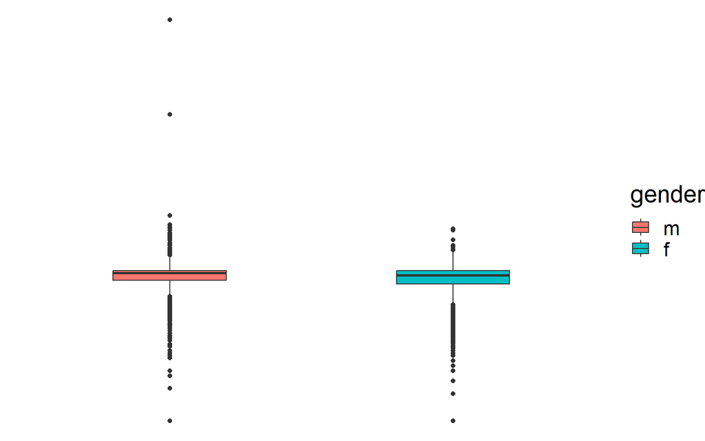

```r
cdc %>%
  ggplot(aes(x = gender, y = pdif, fill = gender)) +
  geom_boxplot(width = 0.4) +
  theme_void() +
  theme(text = element_text(size = 20))
```

Conforme vemos nas estatísticas calculadas acima, bem como nos boxplots, dentre os participantes do estudo, as mulheres tendem a achar que estão mais acima do peso do que os homens pensam sobre eles mesmos.

6. Agora chegou a hora de usar a criatividade. Encontre a média e o desvio padrão de peso e determine qual a proporção de pesos que estão a um desvio padrão da média. E a dois desvios padrões da média?

Para responder a essas perguntas, basta calcularmos, dentro do nosso dataframe, a proporção de elementos que satisfazem as seguintes condições

$$|P-\bar{P}| < sd(P)$$

$$|P-\bar{P}| < 2*sd(P)$$

```r
nrow(filter(cdc, abs(weight - mean(weight)) < sd(weight)))/nrow(cdc)
```

```
## [1] 0.7076
```

```r
nrow(filter(cdc, abs(weight - mean(weight)) < 2*sd(weight)))/nrow(cdc)
```

```
## [1] 0.9563
```

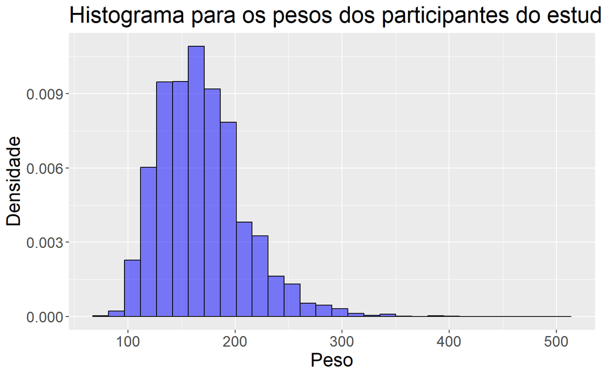

```r
cdc %>%
  ggplot(aes(x = weight)) +
  geom_histogram(
    aes(y = after_stat(density)),
    fill = "blue",
    alpha = 0.5,
    col = "black"
    ) +
  labs(
    x = "Peso",
    y = "Densidade",
    title = "Histograma para os pesos dos participantes do estudo"
    ) +
  theme(text = element_text(size = 18))
```

# Lab03: Probabilidade: Mãos Quentes (Hot Hands)

## Conteúdos abordados neste laboratório

- Probabilidade
- Eventos independentes
- Simulações de eventos independentes no R

## Mãos Quentes (Hot Hands)

Jogadores de basquete que pontuam várias vezes seguidas costumam ser descritos como tendo as *mãos quentes*. Fãs e jogadores acreditam há muito tempo no fenômeno das mãos quentes, que refuta o pressuposto de que cada lance é independente do próximo. Contudo, um artigo de 1985 escrito por Gilovich, Vallone e Tversky coletou evidências que contradizem essa crença e mostrou que lances sucessivos são eventos independentes. Este artigo iniciou uma grande controvérsia que continua até hoje, como você pode verificar se procurar por *hot hand basketball* no Google.

Não temos a expectativa de resolver esta controvérsia hoje. Entretanto, neste laboratório nós aplicaremos um procedimento para responder a questões como essa. Os objetivos deste laboratório são (1) **refletir sobre o efeito de eventos dependentes e independentes**, (2) **aprender como simular sequências de lances no R**, e (3) **comparar a simulação com os dados efetivos para determinar se o fenômeno das mãos quentes parece ser real**.

## Começando

Nossa investigação terá como foco a performance de um jogador: Kobe Bryant do Los Angeles Lakers. Sua performance contra o Orlando Magic nas finais de 2009 da NBA lhe deram o título de Jogador Mais Valioso (ou, em inglês, *Most Valuable Player*) e vários espectadores comentaram como ele parecia demonstrar a característica de mãos quentes. Vamos carregar alguns dados desses jogos que iremos utilizar durante este laboratório.

```r
load(file = "hot_hand.Rdata")
```

Você deve ver dois objetos na aba Environment: `kobe_basket` e `calc_streak`:

```r
names(kobe_basket)
```

```
## [1] "vs"          "game"        "quarter"     "time"        "description"
## [6] "shot"
```

```r
head(kobe_basket) %>%
  kable() %>%
  kable_styling(
    full_width = F,
    bootstrap_options = c("striped", "hover", "condensed",
                          "responsive")
  )
```

| vs | game | quarter | time | description | shot |
| --- | --- | --- | --- | --- | --- |
| ORL | 1 | 1 | 9:47 | Kobe Bryant makes 4-foot two point shot | H |
| ORL | 1 | 1 | 9:07 | Kobe Bryant misses jumper | M |
| ORL | 1 | 1 | 8:11 | Kobe Bryant misses 7-foot jumper | M |
| ORL | 1 | 1 | 7:41 | Kobe Bryant makes 16-foot jumper (Derek Fisher assists) | H |
| ORL | 1 | 1 | 7:03 | Kobe Bryant makes driving layup | H |
| ORL | 1 | 1 | 6:01 | Kobe Bryant misses jumper | M |

Apenas olhando para a sequência de acertos e erros pode ser difícil de auferir se é provável que Kobe estava arremessando com as mãos quentes. Uma possível maneira de abordarmos este problema é supormos que arremessadores com as mãos quentes tendem a conseguir uma longa sequência de acertos. Para este laboratório, definiremos o comprimento de uma sequência de acertos como o *número de cestas consecutivas até acontecer um erro*.

Por exemplo, no Jogo 1, Kobe teve a seguinte sequência de acertos e erros de suas nove tentativas de arremessos no primeiro quarto:

**H M** | **M** | **H H M** | **M** | **M** | **M**

Para verificar esta informação, use o seguinte comando:

```r
kobe_basket%>%
  filter(game == 1, quarter == 1) %>%
  select(shot)
```

```
##   shot
## 1    H
## 2    M
## 3    M
## 4    H
## 5    H
## 6    M
## 7    M
## 8    M
## 9    M
```

Dentre as nove tentativas de arremesso existem seis sequências, que são separadas por um “|” acima. Seus comprimentos são um, zero, dois, zero, zero, zero (em ordem de ocorrência). Vemos então que em uma sequência de comprimento 1 existe 1 acerto e 1 erro, ao passo que na sequência de comprimento 0 existe 0 acerto e 1 erro. Uma sequência de comprimento 2, por sua vez, contêm 2 acertos e 1 erro. Portanto, uma sequência de comprimento L contêm L acertos e 1 erro.

Contar os comprimentos de todos os 133 arremessos manualmente seria extremamente tedioso, então iremos utilizar a função `calc_streak` para realizar este trabalho para nós. Os resultados serão armazenados em um conjunto de dados chamado `kobe_streak` como a variável `length` (comprimento em inglês).

```r
kobe_streak = kobe_basket %>%
  select(shot) %>%
  calc_streak()
```

Nós podemos dar uma olhada na distribuição desses comprimentos com o comando abaixo.

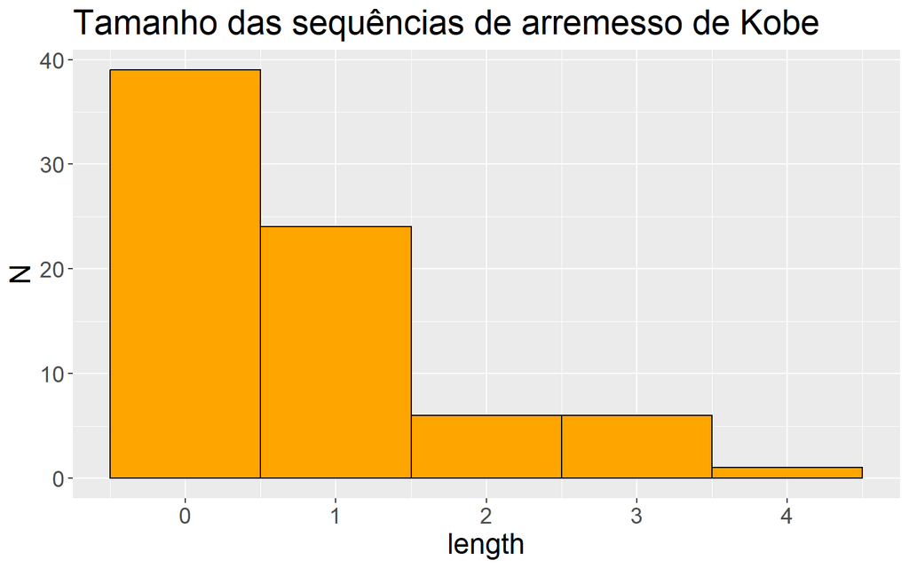

```r
kobe_streak %>%
  ggplot(aes(x = length)) +
  geom_histogram(binwidth = 1, col = "black", fill = "orange") +
  labs(
    title = "Tamanho das sequências de arremesso de Kobe",
    y = "N"
    ) +
  theme(text = element_text(size=18))
```

```r
summary(kobe_streak)
```

```
##      length
##  Min.   :0.0000
##  1st Qu.:0.0000
##  Median :0.0000
##  Mean   :0.7632
##  3rd Qu.:1.0000
##  Max.   :4.0000
```

```r
table(kobe_streak)
```

```
## length
##  0  1  2  3  4
## 39 24  6  6  1
```

Conforme podemos ver na saída de código acima, o comprimento típico das sequências de Kobe foi zero. Além disso, podemos ver também que a mediana dos comprimentos das sequências é também zero, enquanto a média é um número menor que 1.

## Ao que comparar

Nós mostramos que Kobe teve algumas sequências longas de arremesso, mas elas são longas o suficiente para apoiar a crença de que ele tinha mãos quentes? Com o que podemos compará-las?

Para responder a essa pergunta, vamos retornar ao conceito de *independência*. Dois eventos são independentes se o resultado de um evento não afeta o resultado do outro. Se cada arremesso do jogador for um evento independente, acertar ou errar o primeiro arremesso não afetará a probabilidade de ele converter ou errar o segundo arremesso.

Um arremessador com as mãos quentes terá arremessos que *não* são independentes um do outro. Mais especificamente, se o arremessador converte seu primeiro arremesso, o modelo acerca das mãos quentes afirma que ele terá uma probabilidade *maior* de converter seu segundo arremesso.

Vamos supor por um momento que o modelo das mãos quentes é válido para Kobe. Durante sua carreira, o percentual de vezes que Kobe acertou uma cesta (ou seja, seu percentual de arremessos convertidos) é de cerca de 45%, ou, em notação de probabilidade,

**P(arremesso 1 = H) = 0.45**

Se ele converte o primeiro arremesso e tem as mãos quentes (arremessos não independentes), então a probabilidade de ele converter seu segundo arremesso deveria aumentar para, digamos, 60%,

**P(arremesso 2 = H | arremesso 1 = H) = 0.60**

Como um resultado do aumento da probabilidade, seria esperado que Kobe obtivesse sequências mais longas. Compare com a perspectiva cética de que Kobe *não* tenha as mãos quentes, ou seja, que cada arremesso é independente do anterior. Se ele acerta seu primeiro arremesso, a probabilidade de ele acertar o segundo continua sendo 0.45.

**P(arremesso 2 = H | arremesso 1 = H) = 0.45**

Em outras palavras, converter o primeiro arremesso não afeta de maneira alguma a probabilidade de ele converter o segundo arremesso. Se os arremessos de Kobe forem independentes, então ele teria a mesma probabilidade de acertar cada arremesso independentemente de seus arremessos anteriores: 45%.

Agora que reformulamos a situação em termos de arremessos independentes, vamos retornar à questão: como podemos saber se as sequências de arremessos de Kobe são longas o suficiente para indicar que ele tem mãos quentes? Podemos comparar o tamanho de suas sequências a alguém que não tem as mãos quentes: um arremessador independente.

## Simulações no R

Embora não tenhamos dados de um “arremessador independente”, esse tipo de dado é muito fácil de ser simulado no R. Numa simulação, você define as regras básicas de um processo aleatório e então o computador utiliza números aleatórios para gerar um resultado fiel a essas regras. Como um exemplo simples, vamos simular o lançamento de uma moeda honesta onde `K` simboliza cara e `C` simboliza coroa:

```r
face_moeda = c("K", "C")
sample(face_moeda, size = 1, replace = T)
```

```
## [1] "C"
```

Primeiramente registramos os possíveis resultados no vetor `face_moeda`. O comando `sample` realiza uma amostra do experimento ao selecionar aleatoriamente um dos valores `K` ou `C`. O vetor `face_moeda` pode ser entendido como um chapéu com duas tiras de papel dentro dele: numa tira está escrito `K` e na outra `C`. A função `sample` sorteia uma tira de dentro do chapéu e revela se ela é cara ou coroa.

Execute o segundo comando listado acima várias vezes. Da mesma maneira que quando jogamos uma moeda, algumas vezes você obterá cara, algumas vezes você obterá coroa, mas a longo prazo você esperaria obter um número mais ou menos igual de cada possível resultado.

Se você quisesse simular o lançamento de uma moeda honesta 100 vezes, você poderia rodar a função 100 vezes ou, de forma mais simples, ajustar o argumento `size` (tamanho), que regula quantas amostras retirar. O argumento `replace` indica se há (TRUE) ou não (FALSE) reposição dos possíveis valores. Voltando à analogia do chapéu, TRUE indica que nós recolocamos a tira de papel de volta no chapéu antes de retirar as amostras seguintes. Salve o vetor resultante de caras e coroas num novo objeto denominado sim_moeda_honesta.

```r
sim_moeda_honesta = sample(face_moeda, 100, replace = T)

sim_moeda_honesta
```

```
##   [1] "C" "C" "C" "K" "C" "K" "K" "K" "K" "C" "K" "C" "C" "K" "C" "K" "C" "K"
##  [19] "C" "K" "K" "C" "K" "C" "C" "C" "K" "C" "C" "K" "K" "C" "C" "K" "K" "K"
##  [37] "C" "K" "C" "C" "K" "K" "C" "K" "K" "C" "C" "K" "K" "K" "K" "K" "K" "K"
##  [55] "C" "C" "C" "C" "K" "C" "K" "C" "K" "C" "C" "K" "C" "K" "C" "C" "C" "K"
##  [73] "K" "K" "K" "K" "K" "C" "K" "C" "C" "K" "C" "C" "K" "C" "K" "K" "C" "K"
##  [91] "C" "C" "K" "C" "C" "K" "K" "K" "K" "C"
```

Para visualizar os resultados desta simulação, digite o nome do objeto e então use o comando table pra contar o número de caras e coroas.

```r
table(sim_moeda_honesta)
```

```
## sim_moeda_honesta
##  C  K
## 48 52
```

Uma vez que há apenas dois elementos no vetor `face_moeda`, a probabilidade de que um lançamento dê o resultado cara é 0,5. Digamos que estamos tentando simular uma moeda viciada, onde a probabilidade de sair cara é 20%. Podemos ajustar a amostra adicionando um argumento denominado `prob`, que fornece um vetor com as respectivas probabilidades.

```r
sim_moeda_viciada = sample(face_moeda, size = 100, replace = T, prob = c(0.2, 0.8))
```

`prob = c(0.2, 0.8)` indica que, para os dois elementos no vetor `face_moeda`, nós queremos selecionar o primeiro (cara) com probabilidade 0,2, e o segundo (coroa), com probabilidade 0,8. Outra maneira de pensar sobre esse cenário é imaginar o espaço amostral como um saco contendo 10 fichas, sendo 2 marcadas como “cara” e 8 como “coroa”. Portanto, a cada seleção, a probabilidade de retirar uma ficha escrito “cara” é 20%, e “coroa” é 80%.

> **Uma nota sobre sementes:** Especificar uma semente irá fazer com que o R obtenha a mesma amostra cada vez que você aperta o botão *Knit*. Isso garante a reprodutibilidade do seu trabalho, uma vez que os seus resultados serão os mesmos cada vez que você compilar os seus comandos. Você pode especificar uma semente com o comando abaixo:

```r
set.seed(123) #Podemos usar qualquer valor como semente, desde que
#utilizemos sempre o mesmo ao longo das nossas simulações.
```

```r
set.seed(123)

sim_moeda_viciada_reprod = sample(face_moeda, 100, replace = T, prob = c(0.2,0.8))

sim_moeda_viciada_reprod
```

```
##   [1] "C" "C" "C" "K" "K" "C" "C" "K" "C" "C" "K" "C" "C" "C" "C" "K" "C" "C"
##  [19] "C" "K" "K" "C" "C" "K" "C" "C" "C" "C" "C" "C" "K" "K" "C" "C" "C" "C"
##  [37] "C" "C" "C" "C" "C" "C" "C" "C" "C" "C" "C" "C" "C" "K" "C" "C" "C" "C"
##  [55] "C" "C" "C" "C" "K" "C" "C" "C" "C" "C" "K" "C" "K" "K" "C" "C" "C" "C"
##  [73] "C" "C" "C" "C" "C" "C" "C" "C" "C" "C" "C" "C" "C" "C" "K" "K" "K" "C"
##  [91] "C" "C" "C" "C" "C" "C" "C" "C" "C" "C"
```

```r
table(sim_moeda_viciada_reprod)
```

```
## sim_moeda_viciada_reprod
##  C  K
## 82 18
```

Num certo sentido, nós reduzimos o tamanho da tira de papel que diz “cara”, tornando-o menos provável de ser escolhido, e nós aumentamos o tamanho da tira de papel que diz “coroa”, tornando-o mais provável de ser retirado. Quando simulamos a moeda honesta, ambas as tiras de papel tinham o mesmo tamanho. Isso acontece de maneira padrão se você não fornecer o argumento `prob`; todos os elementos no vetor `face_moeda` terão igual probabilidade de serem escolhidos.

## Simulando o arremessador independente

Para simular um jogador de basquete que arremessa de forma independente, utilizamos o mesmo mecanismo que empregamos para simular o lançamento de uma moeda. Para simular um único arremesso de um arremessador independente, com um percentual de acerto de 50%, digitamos

```r
arremesso = c("H", "M")
sim_cesta = sample(arremesso, 1, replace = T)
```

Para fazermos uma comparação válida entre Kobe e nosso arremessador independente simulado, precisamos alinhar tanto seus percentuais de arremesso quanto seus números de arremessos tentados.

Considerando os 133 arremessos de Kobe nas finais de 2009 da NBA, bem como seu percentual histório de acertos, que era de 45%, podemos simular como seria sua versão independente da seguinte forma:

```r
set.seed(123)
sim_cesta = sample(arremesso, size = 133, replace = T, prob = c(0.45, 0.55))
```

Observe que nomeamos o novo vetor como `sim_cesta`, com o mesmo nome que demos ao vetor anterior correspondente a um percentual de arremesso de 50%. Nessa situação, o R sobrescreve o objeto antigo com o novo, portanto sempre se certifique que você não precisa da informação no vetor antigo antes de atribuir um novo objeto ao seu nome.

Com os resultados da simulação salvos como `sim_cesta`, temos os dados necessários para comparar Kobe ao nosso arremessador independente. Podemos visualizar os dados de Kobe em conjunto com os nossos dados simulados.

Ambos os conjuntos de dados representam o resultado de 133 tentativas de arremessos, cada uma com o mesmo percentual de acerto de 45%. Sabemos que nossos dados simulados são de um arremessador que arremessa de forma independente. Quer dizer, sabemos que o arremessador simulado não tem as mãos quentes.

## Por sua conta

1. Utilizando a função `calc_streak`, calcule os comprimentos das sequências de arremessos convertidos de `sim_cesta` e salve os resultados em um conjunto de dados chamado `sim_streak`. Note que `sim_streak` é apenas um vetor e não uma variável de um conjunto de dados como o que utilizamos para calcular as sequências de Kobe. Desse modo, não é preciso selecionar a variável dentro de um conjunto de dados, bastando apenas aplicar a função ao vetor.

```r
sim_streak = calc_streak(sim_cesta)
```

2. Descreva a distribuição das sequências de arremessos. Qual é o comprimento de sequência típico para o arremessador independente simulado com um percentual de arremesso de 45%? Qual o comprimento da sequência mais longa de cestas em 133 arremessos? Não esqueça de incluir um gráfico à sua resposta.

Para começar, vamos ver um resumo estatístico das sequências de Kobe e do arremessador independente:

```r
summary(kobe_streak)
```

```
##      length
##  Min.   :0.0000
##  1st Qu.:0.0000
##  Median :0.0000
##  Mean   :0.7632
##  3rd Qu.:1.0000
##  Max.   :4.0000
```

```r
summary(sim_streak)
```

```
##      length
##  Min.   :0.0000
##  1st Qu.:0.0000
##  Median :0.0000
##  Mean   :0.8108
##  3rd Qu.:1.0000
##  Max.   :7.0000
```

Vemos então que o tamanho máximo de uma sequência de Kobe foi igual a 4, ao passo que o arremessador independente alcançou um máximo de 7. As medianas são iguais e as médias muito parecidas.

Podemos ainda executar o comando `table`, combinado com o comando `prop.table()`, a fim de verificar, em cada conjunto de dados, o tamanho de sequência que mais ocorre:

```r
prop.table(table(kobe_streak))
```

```
## length
##          0          1          2          3          4
## 0.51315789 0.31578947 0.07894737 0.07894737 0.01315789
```

```r
prop.table(table(sim_streak))
```

```
## length
##          0          1          2          3          4          7
## 0.54054054 0.28378378 0.08108108 0.05405405 0.02702703 0.01351351
```

Vemos, portanto, que as sequências ocorrem com frequências muito parecidas nos dois conjuntos de dados. Por exemplo, aproximadamente 51% das sequências de Kobe naquela final de temporada teve comprimento zero. No caso do simulador independente, esse percentual foi perto de 54%. Já as sequências de tamanho 2 ocorreram com frequência de aproximadamente 8% em ambos os casos. Por meio dessa análise, podemos concluir que os dois arremessadores são compatíveis.

Por fim, vamos comparar os histogramas para os comprimentos dos arremessos de Kobe e do arremessador independente:

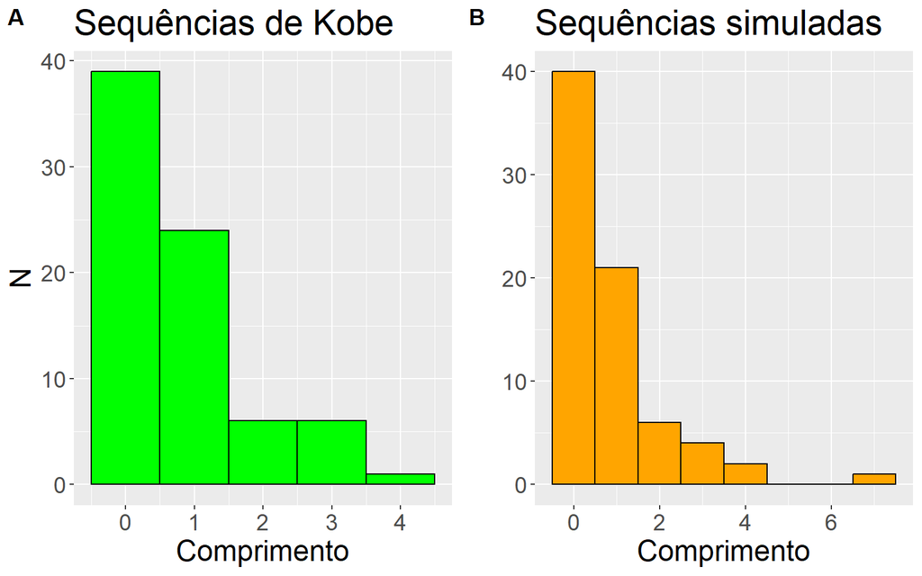

```r
hist_kobe = ggplot(kobe_streak, aes(x = length)) +
  geom_histogram(col = "black", fill = "green", binwidth = 1) +
  labs(
    x = "Comprimento",
    y = "N",
    title = "Sequências de Kobe"
  ) +
  theme(text = element_text(size=18))

hist_sim = ggplot(sim_streak, aes(x = length)) +
  geom_histogram(col = "black", fill = "orange", binwidth = 1) +
  labs(
    x = "Comprimento",
    y = "",
    title = "Sequências simuladas"
  ) +
  theme(text = element_text(size=18))

cowplot::plot_grid(hist_kobe, hist_sim, labels = "AUTO")
```

# Lab04: Distribuições Amostrais

Neste laboratório, investigaremos os meios pelos quais as estatísticas de uma amostra aleatória de dados podem servir como estimativas pontuais de parâmetros populacionais. Estamos interessados em formular uma distribuição amostral de nossa estimativa para aprender sobre as propriedades da estimativa, como sua distribuição.

## Conteúdos abordados neste laboratório

- Amostragem no R
- Distribuição amostral da média
- Distribuição normal
- Teorema do Limite Central
- Histogramas
- Box plots

> **Especificando uma semente:** Nós iremos tomar amostras aleatórias e gerar algumas distribuições amostrais neste laboratório. Desse modo, você deverá especificar uma semente logo no início de seu relatório. Caso tenha dúvidas sobre como definir esta semente, retorne ao laboratório anterior onde explicamos este conceito.

```r
set.seed(123)
```

## Os dados

Vamos analisar dados do setor imobiliário da cidade de Ames, no estado de Iowa, Estados Unidos. Os detalhes de cada transação imobiliária na cidade de Ames são registrados pelo escritório da Secretaria Municipal da Receita da cidade. Nosso foco particular para este laboratório será todas as vendas de casa em Ames entre 2006 e 2010. Essa coleção representa nossa população de interesse. Neste laboratório queremos aprender sobre essas vendas de casas retirando pequenas amostras da população completa. Vamos importar os dados.

```r
load("ames.rda")
names(ames)
```

```
##  [1] "Order"           "PID"             "area"            "price"
##  [5] "MS.SubClass"     "MS.Zoning"       "Lot.Frontage"    "Lot.Area"
##  [9] "Street"          "Alley"           "Lot.Shape"       "Land.Contour"
## [13] "Utilities"       "Lot.Config"      "Land.Slope"      "Neighborhood"
## [17] "Condition.1"     "Condition.2"     "Bldg.Type"       "House.Style"
## [21] "Overall.Qual"    "Overall.Cond"    "Year.Built"      "Year.Remod.Add"
## [25] "Roof.Style"      "Roof.Matl"       "Exterior.1st"    "Exterior.2nd"
## [29] "Mas.Vnr.Type"    "Mas.Vnr.Area"    "Exter.Qual"      "Exter.Cond"
## [33] "Foundation"      "Bsmt.Qual"       "Bsmt.Cond"       "Bsmt.Exposure"
## [37] "BsmtFin.Type.1"  "BsmtFin.SF.1"    "BsmtFin.Type.2"  "BsmtFin.SF.2"
## [41] "Bsmt.Unf.SF"     "Total.Bsmt.SF"   "Heating"         "Heating.QC"
## [45] "Central.Air"     "Electrical"      "X1st.Flr.SF"     "X2nd.Flr.SF"
## [49] "Low.Qual.Fin.SF" "Bsmt.Full.Bath"  "Bsmt.Half.Bath"  "Full.Bath"
## [53] "Half.Bath"       "Bedroom.AbvGr"   "Kitchen.AbvGr"   "Kitchen.Qual"
## [57] "TotRms.AbvGrd"   "Functional"      "Fireplaces"      "Fireplace.Qu"
## [61] "Garage.Type"     "Garage.Yr.Blt"   "Garage.Finish"   "Garage.Cars"
## [65] "Garage.Area"     "Garage.Qual"     "Garage.Cond"     "Paved.Drive"
## [69] "Wood.Deck.SF"    "Open.Porch.SF"   "Enclosed.Porch"  "X3Ssn.Porch"
## [73] "Screen.Porch"    "Pool.Area"       "Pool.QC"         "Fence"
## [77] "Misc.Feature"    "Misc.Val"        "Mo.Sold"         "Yr.Sold"
## [81] "Sale.Type"       "Sale.Condition"
```

Como você pode observar, o banco de dados está em sua língua originária, inglês, e existe uma quantidade consideravelmente grande de variáveis. Para este laboratório, restringiremos nossa atenção para somente duas variáveis: a área habitável da casa acima do nível do solo em pés quadrados (`area`) e o preço da venda (`price`) em dólares.

Nós podemos explorar a distribuição da área das casas em nossa população de vendas de casas calculando algumas estatísticas sumárias e criando um histograma. Vamos iniciar criando uma visualização por meio do histograma:

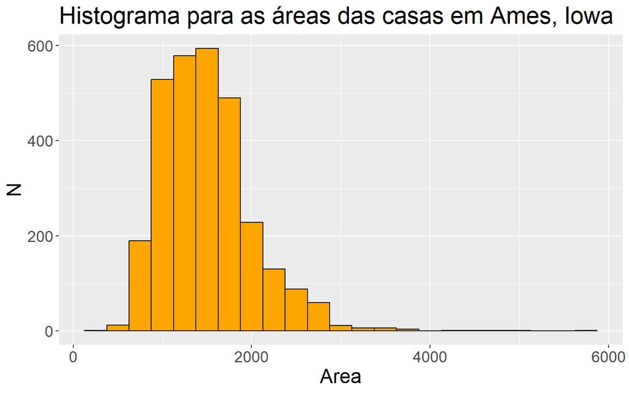

```r
ames %>%
  ggplot(aes(x = area)) +
  geom_histogram(fill = "orange", col = "black", binwidth = 250) +
  labs(
    x = "Area",
    y = "N",
    title = "Histograma para as áreas das casas em Ames, Iowa"
  ) +
  theme(text = element_text(size = 18))
```

Vamos obter, também, algumas medidas descritivas. Observe que podemos fazer isso por meio da função `summarise`. O número de estatísticas a serem calculadas fica a nosso critério. Algumas das funções abaixo já foram discutidas no primeiro laboratório (como `mean`, `median`, `sd`, `IQR`, `min`, e `max`). A função `quantile` aparece pela primeira vez em nossos laboratórios, correspondendo ao quantil especificado da distribuição de interesse. Por exemplo, a expressão `quantile(x, 0.25)` irá nos revelar o valor que acumula 25% (Q1) da distribuição da variável `X`. Conforme pode ser acompanhado em qualquer livro-texto de estatística básica, esses valores são úteis na descrição da distribuição dos dados: como exemplo, poderíamos estar interessados na “região central que acumula 50% das casas com área dada em pés quadrados”. Na saída abaixo, usamos também a função `kable`, do pacote `kableExtra`, para apresentar a saída da função `summarise` na forma de uma tabela:

```r
n = nrow(ames)
ames %>%
  summarise(
    mu = mean(area),
    pop_med = median(area),
    sigma = ((n-1)/n)*sd(area),
    pop_iqr = IQR(area),
    pop_min = min(area), pop_max = max(area),
    pop_q1 = quantile(area, 0.25),# primeiro quartil, 25º percentil
    pop_q3 = quantile(area, 0.75) # terceiro quartil, 75º percentil
    ) %>%
  kable() %>%
  kable_styling(
    full_width = F,
    bootstrap_options = c("striped", "hover", "condensed",
                          "responsive")
  )
```

| mu | pop_med | sigma | pop_iqr | pop_min | pop_max | pop_q1 | pop_q3 |
| --- | --- | --- | --- | --- | --- | --- | --- |
| 1499.69 | 1442 | 505.3364 | 616.75 | 334 | 5642 | 1126 | 1742.75 |

- **Exercício 1**: Descreva a distribuição desta população usando visualizações e estatísticas descritivas. Você não precisa usar todas as estatísticas descritivas existentes, mas deve decidir quais delas são relevantes baseando-se na forma da distribuição. Não esqueça de incluir os gráficos e saídas das estatísticas calculadas no seu relatório juntamente com a sua narrativa.

```r
ames %>%
  select(area) %>%
  filter(abs(area - mean(area)) < ((n-1)/n)*sd(area)) %>%
  nrow()/nrow(ames)
```

```
## [1] 0.7167235
```

Como podemos notar a partir do histograma plotado e da saída do código logo acima, assim como através das estatísticas descritivas selecionadas na função `summarise`, a distribuição das áreas das habitações do nosso conjunto de dados é aproximadamente normal, porém, com uma leve assimetria à direita, devido aos poucos imóveis que possuem área muito maior que os demais (*outliers*). Isso pode ser reforçado pela visualização de um boxplot:

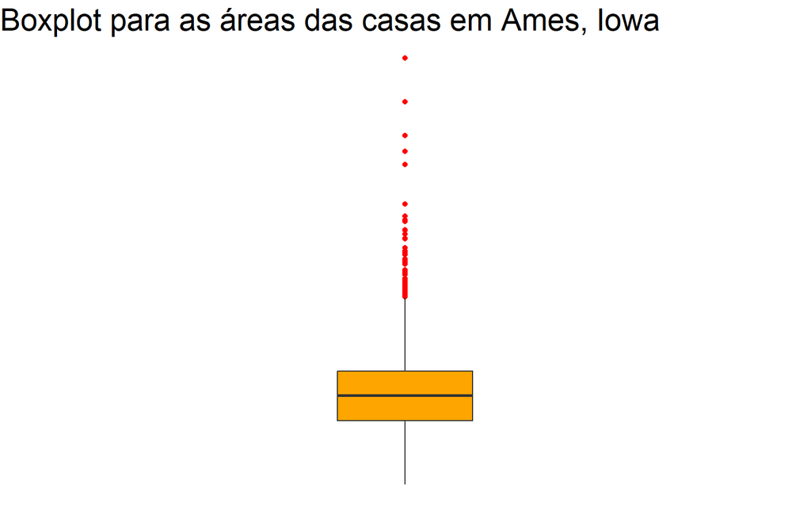

```r
ames %>%
  ggplot(aes(x = "", y = area)) +
  geom_boxplot(width = 0.2, fill = "orange", outlier.color = "red") +
  labs(
    title = "Boxplot para as áreas das casas em Ames, Iowa",
    x = "Area"
  ) +
  theme_void() +
  theme(text = element_text(size = 18))
```

## A distribuição Amostral Desconhecida

Neste laboratório nós temos acesso à população inteira, mas isso raramente acontece na vida real. Reunir informação sobre uma população inteira costuma ser muito custoso ou impossível. Por essa razão, frequentemente retiramos uma amostra da população e a utilizamos para compreender propriedades da população.

Se estivermos interessados em estimar a área habitável média na cidade de Ames com base numa amostra, podemos utilizar o seguinte comando para sondar a população.

```r
set.seed(123)
amostra1 = slice_sample(ames, n = 50, replace = T)
```

Esse comando retira uma amostra aleatória simples de tamanho 50 do dataframe `ames`, que é atribuída à variável `amostra1`. É como se fossemos ao banco de dados da Secretaria Municipal da Fazenda e retirássemos os arquivos de 50 vendas de casas aleatoriamente. Trabalhar com esses 50 arquivos seria consideravelmente mais simples do que lidar com todas as 2930 vendas de casas.

- **Exercício 2**: Descreva a distribuição desta amostra. Como ela se compara à distribuição da população? Dica A função `slice_sample` retira uma amostra das observações (i.e. linhas) no banco de dados. Você pode utilizar os mesmos nomes para as variáveis do banco de dados. Os códigos utilizados no exercício anterior podem ser muito úteis para visualizar e descrever a distribuição, mas tenha cuidado ao nomear as estatísticas uma vez que `mu` e `sigma` são parâmetros populacionais já definidos e o que você tem é uma amostra e, consequentemente, estatísticas amostrais. Você pode nomear à sua escolha as estatísticas calculadas, sendo muito útil indicar no nome atribuído que seus valores são oriundos de uma amostra.

Se estamos interessados em estimar a área habitável média nas casas da cidade de Ames utilizando esta amostra, nosso melhor palpite é a média da amostra.

```r
summarise(amostra1, x_bar = mean(area))
```

```
## # A tibble: 1 × 1
##   x_bar
##   <dbl>
## 1 1459.
```

Dependendo de quais foram as 50 casas que foram sorteadas, sua estimativa pode estar um pouco acima ou abaixo da média populacional verdadeira de 1499,69 pés quadrados. De maneira geral, mesmo assim, a média da amostra costuma ser uma estimativa muito boa da média da área habitável, e nós a obtemos por meio de uma amostra de menos de 3% da população.

Não é surpreendente que, a cada vez que retiramos uma nova amostra aleatória, obtemos uma média amostral diferente. É útil ter uma ideia de quanta variabilidade podemos esperar quando estimamos a média populacional desta maneira. A distribuição das médias amostrais, denominada de *distribuição amostral*, pode nos ajudar a compreeder essa variabilidade. Neste laboratório, uma vez que temos acesso à população, podemos elaborar a distribuição amostral para a média amostral repetindo os passos acima várias vezes. Agora iremos gerar 2000 amostras e calcularemos a média amostral de cada uma delas. Note que utilizamos o argumento `replace = TRUE` pelo simples fato de que amostras aleatórias simples são obtidas da distribuição original para cada réplica.

```r
set.seed(123)
amostra50 = rdply(2000, slice_sample(ames, n = 50, replace = T), .id = "id_sample")
```

para determinar as médias de cada uma das 2000 amostras de 50 elementos, utilizamos as funções da biblioteca `dplyr`, além do operador `%>%`:

```r
medias_amostra50 = amostra50 %>%
  group_by(id_sample) %>%
  summarise(x_bar = mean(area))
```

## Interlúdio: A função `rdply`

Na seção anterior, utilizamos a função `rdply`, do pacote `plyr`, para gerar `L = 2000` amostras de tamanho `n = 50` do nosso conjunto de dados `ames`. Para tanto, continuamos a utilizar a função `slice_sample`, da biblioteca `dplyr`. Contudo, como nesse caso não precisávemos apenas de uma amostra, mas de 2000, selecionadas aleatoriamente do nosso dataframe, foi necessário a utilização da função `rdply`.

A função `rdply`permite replicar o cálculo de uma expressão sem a necessidade de utilizar uma estrutura de repetição (ou *loop*), de modo a tornar a programação mais limpa e rápida. Além disso, os resultados dos cálculos efetuados são alocados em um novo dataframe, associados a um identificador (argumento `.id`, inserido na função `rdply`).

Para separar o dataframe criado em 2000 amostras isoladas, podemos usar a função `split`, da biblioteca `plyr`. Poderíamos fazer, por exemplo, `amostra50 = split(amostra50, rep(1:2000, each = nrow(amostra50)/2000))`. Neste caso, seria criada uma lista com os 2000 dataframes. Essa talvez não seja a opção mais interessante, uma vez que irá ocupar muito espaço de memória. Uma alternativa, por exemplo, é fazer o *slice* do dataframe que é retornado da função `rdply`, por meio da coluna `.id`.

## Tamanho da Amostra e a Distribuição Amostral

Deixando de lado os aspectos técnicos de programação, vamos retomar a razão pela qual utilizamos a função `rdply`: calcular uma distribuição amostral, especificamente, esta aqui.

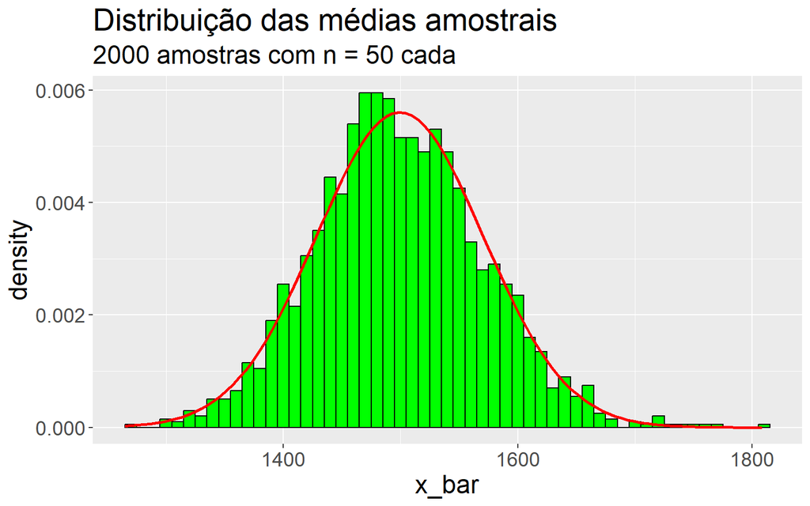

```r
medias_amostra50 %>%
  ggplot(aes(x = x_bar)) +
  geom_histogram(
    aes(y = after_stat(density)),
    binwidth = 10,
    fill = "green",
    col = "black") +
  stat_function(
    fun = dnorm,
    args =
      list(mean = mean(medias_amostra50$x_bar), sd = sd(medias_amostra50$x_bar)),
    linewidth = 1,
    color = "red"
    ) +
  theme(text = element_text(size = 18)) +
  labs(
    title = "Distribuição das médias amostrais",
    subtitle = "2000 amostras com n = 50 cada"
  )
```

A distribuição amostral que calculamos nos informa bastante sobre as estimativas da área habitável das casas na cidade de Ames. Uma vez que a média amostral é um estimador não viesado, a distribuição amostral estará centrada na verdadeira média da área habitável da população, e a dispersão da distribuição indica quanta variabilidade é possível ao se amostrar somente 50 vendas de casas.

Para ter uma ideia melhor do efeito do tamanho da amostra na distribuição amostral, vamos construir distribuições a partir de amostras de diferentes tamanhos:

**Passo 1**: Crie três distribuições amostrais, cada uma contendo 2000 médias amostrais, oriundas de amostras de tamanho $n=10$, $n=50$ e $n=100$.

```r
set.seed(123)
medias_amostra10 = rdply(2000, slice_sample(ames, n = 10, replace = T), .id = "id_sample") %>%
  group_by(id_sample) %>%
  summarise(x_bar = mean(area))
```

```r
set.seed(123)
medias_amostra100 = rdply(2000, slice_sample(ames, n = 100, replace = T), .id = "id_sample") %>%
  group_by(id_sample) %>%
  summarise(x_bar = mean(area))
```

**Passo 2**: Construa o gráfico dessas três distribuições amostrais, uma seguida da outra e, na mesma escala, de modo que possamos comparar as formas, centros e dispersões de cada uma.

- **Passo 2a**: Combine essas três distribuições amostrais (cada uma com 2000 valores) em um novo conjunto de dados contendo 6000 valores. Para combinar bancos de dados, linha por linha, nós usamos a função `rbind`.
- **Passo 2b**: Adicione uma nova coluna chamada `tamanho_amostra` aos dados que você acabou de criar, indicando o tamanho da amostra utilizado ao obter cada entrada. Lembre-se que os primeiros 2000 valores foram obtidos de amostras de tamanho 10, os 2000 seguintes de amostras de tamanho 50 e, finalmente, os 2000 últimos valores foram obtidos de amostras de tamanho 100. Portanto, essa nova variável é simplesmente a repetição do valor 10 por 2000 vezes, seguida de 50 por 2000 vezes e, novamente, 100 por 2000 vezes. O uso da função `factor` indica ao R que a variável é qualitativa, e não numérica. Lembre-se também de usar a função `mutate` para adicionar a nova variável ao banco de dados. O argumento `rep(c(10,50,100), each=2000)` diz ao R que os valores 10, 50 e 100 serão repetidos cada um 2000 vezes.

```r
medias_amostra = rbind(medias_amostra10, medias_amostra50, medias_amostra100) %>%
  select(-id_sample) %>%
  mutate(tamanho_amostra = factor(rep(c(10,50,100), each = 2000)))
```

- **Passo 2c**: Finalmente, construa os três gráficos representando estas três distribuições amostrais. Podemos fazer isso via *faceting*, i.e. criar faces separadas no gráfico para cada uma das distribuições. Lembre-se que nós identificamos cada distribuição a partir da variável `tamanho_amostra`, que acabamos de criar. A expressão `~tamanho_amostra` é nova: ela separa o eixo-y do nosso gráfico em três faces segundo o `tamanho_amostra` e não separa o eixo-x, o que significa que os gráficos serão dispostos um acima do outro ao invés de um ao lado do outro. Decidimos por esta abordagem para facilitar a comparação entre a posição e a dispersão das distribuições.

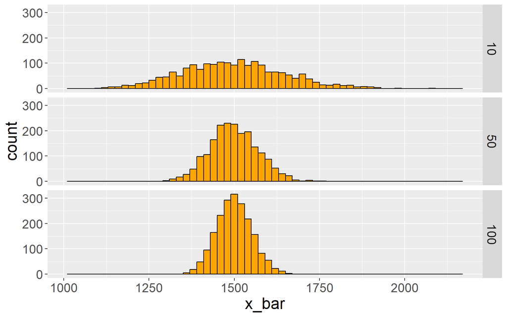

```r
medias_amostra %>%
  ggplot(aes(x = x_bar)) +
  geom_histogram(binwidth = 20, fill = "orange", col = "black") +
  facet_wrap(~tamanho_amostra, ncol = 1, strip.position =  "right") +
  theme(text = element_text(size = 18))
```

Vemos, portanto, que o aumento do tamanho da amostra tem pouca influência sobre o centro da distribuição (a média amostral, que é uma estimativa da média populacional). A dispersão, porém, diminui bastante com o aumento do tamanho da amostra.

Isso mostra, na prática, o que diz o teorema do limite central: a distribuição amostral da média é normal com média igual à média populacional e variância igual a $\sigma/\sqrt{n}$, em que $n$ é o tamanho da amostra e $\sigma$ é o desvio padrão populacional(MORETTIN; BUSSAB, 2017). Em outras palavras, podemos dizer que, se sorteamos aleatoriamente um número grande de amostras suficientemente grande, a distribuição da média amostral será normal, centrada na média da população e com variância inversamente proporcional ao tamanho das amostras.

## Por Sua Conta

Até agora, nós nos ocupamos em estimar a média da área habitável nas casas do município de Ames. Agora você tentará estimar a média dos preços das casas.

1. Retire uma amostra aleatória de tamanho 15 da variável `price` e calcule a média. Com essa amostra, qual é sua melhor estimativa pontual para a média populacional?

Como sabemos, um bom estimador para a média populacional é a média amostral $\bar{X}$, que é um estimador não viesado. Para esse caso, a média amostral seria:

```r
ames %>%
  select(price) %>%
  slice_sample(n = 15, replace = T) %>%
  summarise(x_bar = mean(price))
```

```
## # A tibble: 1 × 1
##     x_bar
##     <dbl>
## 1 185334.
```

2. Já que você tem acesso à população, simule a distribuição amostral de $\bar{X}_{price}$, retirando 2000 amostras de tamanho 15 da população e calculando 2000 médias amostrais. Armazene essas médias em um vetor com o nome `medias_amostra15`. Crie um gráfico com os resultados, e então descreva a forma dessa distribuição amostral. Baseado nessa distribuição amostral, qual seria seu palpite para a média dos preços das casas na população? Por fim, calcule e informe a média populacional.

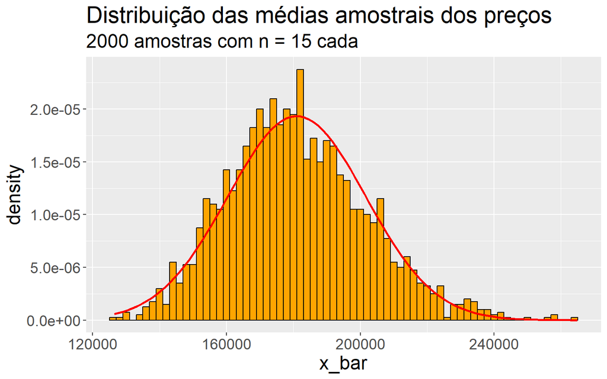

```r
set.seed(123)
medias_amostra15 = rdply(2000, slice_sample(ames, n = 15, replace = T), .id = "id_sample") %>%
  group_by(id_sample) %>%
  summarise(x_bar = mean(price))

medias_amostra15 %>%
  ggplot(aes(x = x_bar)) +
  geom_histogram(
    aes(y = after_stat(density)),
    binwidth = 2000,
    fill = "orange",
    col = "black"
    ) +
  labs(
    title = "Distribuição das médias amostrais dos preços",
    subtitle = "2000 amostras com n = 15 cada"
  ) +
  theme(text = element_text(size = 18)) +
  stat_function(
    fun = dnorm,
    args = list(mean = mean(medias_amostra15$x_bar), sd = sd(medias_amostra15$x_bar)),
    linewidth = 1,
    color = "red"
    )
```

Conforme podemos ver no histograma plotado logo acima, a forma da distribuição da média para essas 2000 amostras de tamanho 15 é de uma normal, como seria de esperar pelo teorema do limite central. Segundo esse histograma, a melhor estimativa para a média populacional seria em torno de $ 180.000,00.

Além disso, a média populacional dos preços dos imóveis do nosso conjunto de dados é igual a 180.796,06 dólares.

3. Mude o tamanho da sua amostra de 15 para 150, e então calcule a distribuição amostral utilizando o mesmo método descrito acima, e guarde as médias em um novo vetor com o nome `medias_amostra150`. Descreva a forma dessa distribuição amostral e compare-a com a distribuição amostral para a amostra de 15 elementos. Com base nessa distribuição amostral, qual seria seu palpite sobre a média dos preços de vendas de casas no município de Ames?

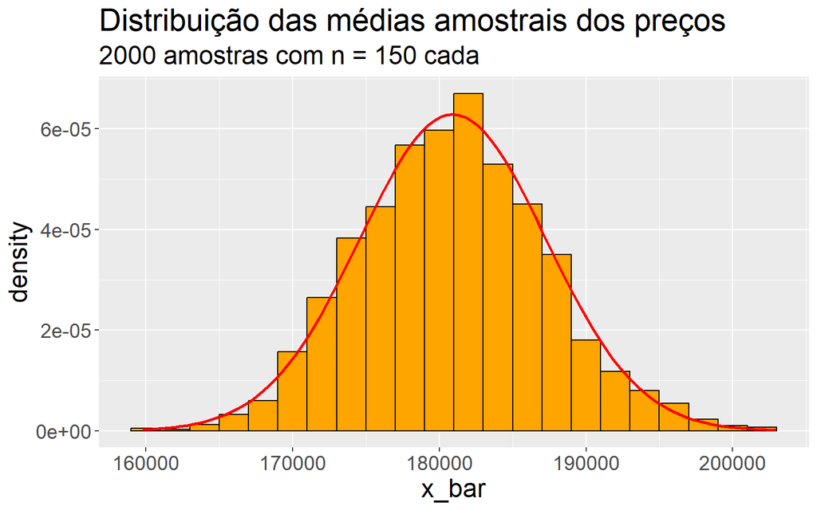

```r
set.seed(123)
medias_amostra150 = rdply(2000, slice_sample(ames, n = 150, replace = T), .id = "id_sample") %>%
  group_by(id_sample) %>%
  summarise(x_bar = mean(price))

medias_amostra150 %>%
  ggplot(aes(x = x_bar)) +
  geom_histogram(
    aes(y = after_stat(density)),
    binwidth = 2000,
    fill = "orange",
    col = "black"
    ) +
  labs(
    title = "Distribuição das médias amostrais dos preços",
    subtitle = "2000 amostras com n = 150 cada"
  ) +
  theme(text = element_text(size = 18)) +
  stat_function(
    fun = dnorm,
    args = list(mean = mean(medias_amostra150$x_bar), sd = sd(medias_amostra150$x_bar)),
    linewidth = 1,
    color = "red"
    )
```

Como podemos ver no histograma acima, a forma da distribuição das médias para amostras de tamanho $n=150$ é também normal, como esperado. Além disso, vemos também que nossa melhor estimativa para a média populacional continua sendo em torno de 180.000 dólares.

Comparando este caso com o da distribuição das médias dos preços para amostras de tamanho $n = 15$, vemos que a maior diferença está na dispersão em torno da média populacional, que no presente caso é menor.

4. Das distribuições amostrais calculadas nos exercícios 2 e 3, qual tem menor dispersão? Se estamos interessados em estimativas que estão mais próximas do valor verdadeiro, preferiríamos uma distribuição com uma dispersão pequena ou grande?

Conforme já discutido no item acima, a distribuição amostral com menor dispersão é aquela com maior $n$, que nesse caso é aquela com $n = 150$. Se estamos interessados em fazer um inferência a respeito do valor da média populacional, por exemplo, deveríamos preferir amostras com maior $n$, a fim de ter maior precisão.

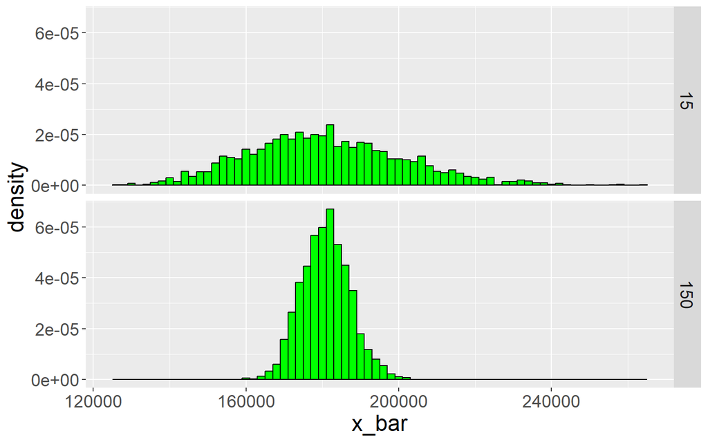

```r
medias_amostra_price = rbind(medias_amostra15, medias_amostra150) %>%
  select(-id_sample) %>%
  mutate(tamanho_amostra = factor(rep(c(15, 150), each = 2000)))

medias_amostra_price %>%
  ggplot(aes(x = x_bar)) +
  geom_histogram(
    aes(y = after_stat(density)),
    fill = "green",
    col = "black",
    binwidth = 2000
    ) +
  facet_wrap(~tamanho_amostra, ncol = 1, strip.position = "right") +
  theme(text= element_text(size = 18))
```